# Credit Risk Data Quality Simulation

2026-03-02

### Part 0: Helper functions and setup

```r
source("01_functions.R")

required_packages <- c("ggplot2", "dplyr", "tidyr", "mice", "xgboost", "DiagrammeR")

for (pkg in required_packages) {
  if (!requireNamespace(pkg, quietly = TRUE)) {
    install.packages(pkg)
  }
  library(pkg, character.only = TRUE)
}
```

# **Stage 1: Creating the “Perfect World” with the DGP**

### Overview

##### **Phase 1. Generating features (predictors) for the business world**

Have to define both the variables and their distributions / dependencies.

1: **Root variables**

1. **firm age**: right skewed so using gamma distribution
2. **sector**: three sectors with proportions and risk properties based off real German practitioner data.
   - Sector 1: Services (Dienstleistungen) at 57% of the sample. Least risky with 2% default rate
   - Sector 2: Hospitality (Gastro), 19% of the sample. Most risky, 3.6% default rate
   - Sector 3: Manufacturing (Verarbeitendes Gewerbe), 24% of the sample. Medium risk, 2.3% default rate

2: **Chained regression dependencies**

Each variable is determined by the one in front of it – older firms tend to be larger, larger firms tend to have lower leverage, etc., plus random noise.

3. **log_assets**: proxy for firm size, dependent on age and sector
4. **debt to equity**: higher leverage is more dangerous – dependent on how big the firm is and how old it is
5. **interest_cov**: proxy for cash flow
6. **Crefo score**. (see below) Dependent on most things above. Sometimes gets lagged (not updated every year)

##### **2. Choose the true coefficients that define the world**

This is the “ground truth”. All are standardized (change in log-odds per 1 SD increase)

##### **3. Create panel data with time series component**

**Inner loop**: creating firms that either stay the same over time, get worse, or improve… (drift rates); default or not during their 3-7 year loan periods.

Crefo will sometimes refresh itself, sometimes remaining stale

**Outer loop** creates lots of these firms. Then the rows are bound together

- the “linpred” – weighted sum of the predictors. this transforms to logistic regression
  - computes the log-odds of default for each borrower
- pd_true: then after: the logistic transformation so we get the true PDs and not log-odds

**Next: Draw observed defaults.** For each borrower, draw a default with pd_true value from before (weighted coin flip) – borrowers can have same PDs but 2 different outcomes (default or not)

##### **4. Reporting and returning a list**

- Data has both raw and scaled versions of every variable
- Scaling = the mean and SD of every predictor so you can apply consistently to the impaired datasets
- Also saving the bounds for winsorization and plausibility (related to data preparation and FRS scores)

True betas = ground truth coefficients

**A quick note on Crefo score (Crefo Bonitätsindex)**

Scale: 100 (excellent) to 600 (insolvent) — higher = worse creditworthiness. Generated as a noisy composite of the same financial signals the bureau uses: leverage, coverage, firm size, and sector. Idiosyncratic noise (sd = 25) reflects bureau information not in our DGP (payment history with other creditors, legal registry data, etc.).

Sector penalties: gastro (40) and manufacturing (20) reflect higher historical default rates in those sectors per practitioner datasets.

## ————————————————————————

### Data Generating Process DAG

**1) Simple DAG for the five indicator variables)**

Color code:

```r
# ── Simple DAG: Origination-level variable dependencies ──────────────

grViz("
digraph DGP_simple {

  graph [rankdir = TB, fontname = 'Helvetica', bgcolor = 'transparent',
         nodesep = 0.8, ranksep = 0.7, margin = '0.2,0.2']
  node  [fontname = 'Helvetica', fontsize = 11, style = filled,
         shape = box, penwidth = 0.6]
  edge  [color = '#888888', penwidth = 0.7, arrowsize = 0.6]

  # ── Root variables ─────────────────────────────────────────────
  firm_age [label = 'firm_age',  fillcolor = '#F1EFE8', color = '#B4B2A9']
  sector   [label = 'sector',    fillcolor = '#E1F5EE', color = '#5DCAA5']

  # ── Derived variables ──────────────────────────────────────────
  log_assets     [label = 'log_assets',     fillcolor = '#E6F1FB', color = '#85B7EB']
  debt_to_equity [label = 'debt_to_equity', fillcolor = '#E6F1FB', color = '#85B7EB']
  interest_cov   [label = 'interest_cov',   fillcolor = '#E6F1FB', color = '#85B7EB']
  crefo          [label = 'crefo',          fillcolor = '#FAECE7', color = '#F0997B']

  # ── Edges ──────────────────────────────────────────────────────
  firm_age -> log_assets
  sector   -> log_assets
  firm_age -> debt_to_equity
  log_assets -> debt_to_equity
  debt_to_equity -> interest_cov
  log_assets -> interest_cov
  log_assets -> crefo
  debt_to_equity -> crefo
  interest_cov -> crefo
  sector -> crefo

  # ── Layout ─────────────────────────────────────────────────────
  {rank = same; firm_age; sector}
  {rank = same; log_assets; debt_to_equity; interest_cov}
}
")
```

[interactive chart not shown]

**2) Entire DGP**

Phase one: (left) variable and dependency declaration

Phase two: (right) panel drift

Phase three: linear predictor combining both of the above phases

```r
# ── Detailed DAG of the Data Generating Process ─────────────────────────────

grViz("
digraph DGP {

  # ── Global settings ──────────────────────────────────────────────
  graph [rankdir = TB, fontname = 'Helvetica', bgcolor = 'transparent',
         nodesep = 0.6, ranksep = 0.7, margin = '0.2,0.2']
  node  [fontname = 'Helvetica', fontsize = 11, style = filled,
         shape = box, penwidth = 0.6]
  edge  [color = '#888888', penwidth = 0.7, arrowsize = 0.6]

  # ── Root variables (drawn once per firm) ────────────────────────
  firm_age   [label = 'firm_age',   fillcolor = '#F1EFE8', color = '#B4B2A9']
  sector     [label = 'sector',     fillcolor = '#E1F5EE', color = '#5DCAA5']
  trajectory [label = 'trajectory', fillcolor = '#EEEDFE', color = '#AFA9EC']

  # ── Derived at origination ─────────────────────────────────────
  log_assets     [label = 'log_assets',     fillcolor = '#E6F1FB', color = '#85B7EB']
  debt_to_equity [label = 'debt_to_equity', fillcolor = '#E6F1FB', color = '#85B7EB']
  interest_cov   [label = 'interest_cov',   fillcolor = '#E6F1FB', color = '#85B7EB']
  crefo          [label = 'crefo',          fillcolor = '#FAECE7', color = '#F0997B']

  # ── Panel drift (t > 1) ───────────────────────────────────────
  pd_curr      [label = 'pd_curr\\n(drift weight)',
                fillcolor = '#F1EFE8', color = '#B4B2A9', shape = ellipse]
  annual_update [label = 'Annual updates\\nlog_assets, d/e, int_cov',
                fillcolor = '#E6F1FB', color = '#85B7EB']
  crefo_refresh [label = 'crefo refresh\\n(p = 0.5)',
                fillcolor = '#FAECE7', color = '#F0997B']

  # ── Linear predictor → default ────────────────────────────────
  gastro_trend [label = 'gastro_trend\\nsector_2 × (year − 2015)',
               fillcolor = '#E1F5EE', color = '#5DCAA5']
  linpred      [label = 'linpred\\nall _z predictors + sector dummies',
               fillcolor = '#FAEEDA', color = '#FAC775']
  default      [label = 'default\\nBernoulli(pd_true)',
               fillcolor = '#FCEBEB', color = '#F09595']

  # ── Phase 1 edges: origination dependencies ────────────────────
  firm_age -> log_assets
  sector   -> log_assets     [label = '  ±0.3', fontsize = 9, fontcolor = '#999999']
  firm_age -> debt_to_equity [label = '  −0.02·z', fontsize = 9, fontcolor = '#999999']
  log_assets -> debt_to_equity [label = '  −0.1·z', fontsize = 9, fontcolor = '#999999']
  debt_to_equity -> interest_cov [label = '  −0.4·z', fontsize = 9, fontcolor = '#999999']
  log_assets -> interest_cov [label = '  +0.3·z', fontsize = 9, fontcolor = '#999999']

  # Crefo at origination: depends on all financials + sector
  log_assets -> crefo
  debt_to_equity -> crefo
  interest_cov -> crefo
  sector -> crefo

  # ── Phase 2 edges: drift mechanism ─────────────────────────────
  trajectory -> annual_update [label = '  drift direction', fontsize = 9, fontcolor = '#7F77DD']
  pd_curr -> annual_update    [label = '  drift intensity\\n  (deteriorating only)', fontsize = 9, fontcolor = '#999999']
  annual_update -> crefo_refresh

  # ── Phase 3 edges: linpred ─────────────────────────────────────
  annual_update -> linpred
  crefo -> linpred
  crefo_refresh -> linpred [style = dashed]
  sector -> linpred
  firm_age -> linpred       [label = '  ages +1/yr', fontsize = 9, fontcolor = '#999999']
  gastro_trend -> linpred
  sector -> gastro_trend

  linpred -> default

  # ── Layout hints ───────────────────────────────────────────────
  {rank = same; firm_age; sector; trajectory}
  {rank = same; log_assets; debt_to_equity; interest_cov}
  {rank = same; pd_curr; annual_update}
  {rank = same; gastro_trend; linpred}
}
")
```

[interactive chart not shown]

## Simulation

```r
result <- simulate_clean_data_panel(N = 50000)
```

```
## Firms simulated:        50000
## Total firm-year rows:   240115
## Default events:         5648 (2.4% of firm-years)
## Firms repaid:           44352
## Obs year range:         2005 to 2031
##
## --- Deterioration diagnostic (defaulting firms only) ---
## Mean pd_true year 1:   0.0924
## Mean pd_true final:    0.1162
## Mean years observed:   3.63
```

```r
# running with high sample size as this is the showcase document
# Monte Carlo runs with less sample but more repetitions

###################################################################

dat    <- result$data

###################################################################

# For later: record what our PD formula is
pd_formula <- default ~ log_assets_z + debt_to_equity_z + interest_cov_z +
                             firm_age_z + crefo_z + sector_2 + sector_3
```

## Checkpoint: Model Fit in the Perfect World

Fitting a logistic regression on clean data:

- even though we know the DGP and all that influence it, basic GLM is unable to perfectly recover it – even on non-impaired data!
- this is a finding in itself: though regulators love the logistic model for its transparency, it is a little too simple for the complications of panel data. We are breaking the assumption of independence and add heterogeneity with firm trajectories, setting off the estimated betas
- Beta recovery on the clean data does not improve with larger sample sizes

```r
## Model fit

fitcheck_scaled <- glm(default ~ log_assets_z + debt_to_equity_z + interest_cov_z +
                         sector_2 + sector_3 + firm_age_z + crefo_z,
                       data = dat, family = binomial())
summary(fitcheck_scaled)
```

```
##
## Call:
## glm(formula = default ~ log_assets_z + debt_to_equity_z + interest_cov_z +
##     sector_2 + sector_3 + firm_age_z + crefo_z, family = binomial(),
##     data = dat)
##
## Coefficients:
##                  Estimate Std. Error  z value Pr(>|z|)
## (Intercept)      -4.13794    0.02341 -176.733  < 2e-16 ***
## log_assets_z     -0.28800    0.01655  -17.403  < 2e-16 ***
## debt_to_equity_z  0.44074    0.01551   28.420  < 2e-16 ***
## interest_cov_z   -0.32611    0.01632  -19.985  < 2e-16 ***
## sector_2          0.47015    0.03547   13.253  < 2e-16 ***
## sector_3          0.17027    0.03629    4.692 2.71e-06 ***
## firm_age_z       -0.11956    0.01629   -7.339 2.15e-13 ***
## crefo_z           0.10446    0.03395    3.077  0.00209 **
## ---
## Signif. codes:  0 '***' 0.001 '**' 0.01 '*' 0.05 '.' 0.1 ' ' 1
##
## (Dispersion parameter for binomial family taken to be 1)
##
##     Null deviance: 53520  on 240114  degrees of freedom
## Residual deviance: 45417  on 240107  degrees of freedom
## AIC: 45433
##
## Number of Fisher Scoring iterations: 8
```

```r
# Compare estimated vs true betas -- this is your coefficient recovery check
true_betas <- result$true_betas

recovery <- data.frame(
  true      = true_betas,
  estimated = coef(fitcheck_scaled),
  diff      = coef(fitcheck_scaled) - true_betas
)
print(round(recovery, 4))
```

```
##                 true estimated    diff
## intercept      -3.90   -4.1379 -0.2379
## log_assets     -0.20   -0.2880 -0.0880
## debt_to_equity  0.40    0.4407  0.0407
## interest_cov   -0.30   -0.3261 -0.0261
## sector_2        0.40    0.4701  0.0701
## sector_3        0.18    0.1703 -0.0097
## firm_age       -0.20   -0.1196  0.0804
## crefo           0.30    0.1045 -0.1955
```

Sidequest: ## Feature reliability score on clean data

**Feature Reliability Score (FRS)** testing from Igl & Gruber’s Handbuch Datenqualität (2025). A customizable data quality measure per indicator variable – in our case, looking at 1) Completeness, 2) Plausibility, 3) Outlier Score, and 4) Cross-Field Consistency for our four continuous predictors. FRS takes the geometric mean for the listed components.

Because this is on clean data, we should expect the scores to be near 1 (perfect quality). We get marked down slightly in Plausibility and Outliers because the FRS function is always looking to penalize data at the tails (it does not take into account that we are in the perfect world). Crefo has different expectations since it is purchased from an external data provider and by default bounded at [100, 600] so it receives the only “perfect score”.

```r
frs_clean <- compute_frs(dat,
                         winsor_bounds       = result$winsor_bounds,
                         plausibility_bounds = result$plausibility_bounds)
print_frs(frs_clean)
```

```
##
## === Feature Reliability Score ===
## Aggregation: geometric mean of completeness, plausibility, outlier, consistency
## Outlier detection: percentile with k = 3
## N = 240115
##
##                completeness plausibility outlier consistency   frs
## log_assets                1         0.98    0.95       0.999 0.982
## debt_to_equity            1         0.99    0.95       0.999 0.985
## interest_cov              1         0.99    0.95       1.000 0.985
## firm_age                  1         0.99    0.95       1.000 0.985
## crefo                     1         1.00    1.00       0.998 0.999
## MEAN                      1         0.99    0.96       0.999 0.987
```

# **Stage 2: Data Impairment**

### MISSINGNESS

#### **Impairment 1: MCAR**

MCAR: missingness applied independently to each cell at random.

Every cell has the same probability of being missing regardless of any other value in the dataset — no row-level or variable-level dependence. This is implemented via independent rbinom draws per variable, producing a random scatter of missingness across the data

Variables included: financial ratios and firm_age. Sector and Crefo are excluded: sector is a simple categorical entry unlikely to be missing; Crefo missingness is modelled separately under the MAR condition.

Mild: ~8% missing per cell; Severe: ~28% missing per cell

Running the MCAR function to create two levels impaired data:

```r
cat("Mild MCAR impairment:\n")
```

```
## Mild MCAR impairment:
```

```r
dat_mcar_mild   <- impair_mcar(dat, severity = "mild")
```

```
## MCAR missing rate for log_assets: 0.080
## MCAR missing rate for debt_to_equity: 0.079
## MCAR missing rate for interest_cov: 0.080
## MCAR missing rate for firm_age: 0.080
```

```r
cat("\nSevere MCAR impairment:\n")
```

```
##
## Severe MCAR impairment:
```

```r
dat_mcar_severe <- impair_mcar(dat, severity = "severe")
```

```
## MCAR missing rate for log_assets: 0.280
## MCAR missing rate for debt_to_equity: 0.279
## MCAR missing rate for interest_cov: 0.281
## MCAR missing rate for firm_age: 0.279
```

#### **Impairment 2: MAR**

MAR: missingness in crefo depends on firm_age (fully observed)

Mechanism: younger firms are less likely to have a Creditreform score because they lack sufficient credit history for the bureau to have issued a rating.

Creating the impaired datasets:

```r
cat("Mild MAR impairment for Crefo:\n")
```

```
## Mild MAR impairment for Crefo:
```

```r
dat_mar_mild   <- impair_mar(dat, severity = "mild")
```

```
## Average MAR missing rate: 0.077
```

```r
cat("\nSevere MAR impairment for Crefo:\n")
```

```
##
## Severe MAR impairment for Crefo:
```

```r
dat_mar_severe <- impair_mar(dat, severity = "severe")
```

```
## Average MAR missing rate: 0.281
```

#### **Impairment 3: MNAR**

MNAR: missingness in interest_cov depends on interest_cov itself.

Mechanism: firms with poor interest coverage strategically omit reporting. This is MNAR because missingness depends on the unobserved value of the variable itself (Little & Rubin, 2002; Zhang, 2023, p. 117).

Only allowing interest coverage to become impaired for a cleaner causal story that is easier to validate (if we see coefficient distortion, we know WHICH missing variable caused it, versus having multiple missing variables x their interactions).

In real life: plausibly the most likely to be affected by MNAR because it requires current earnings data that troubled firms are more likely to delay or withhold.

Persistence: once a firm’s interest_cov goes missing in a given year, it remains missing for all subsequent years of that firm’s life. This reflects real reporting behavior — a firm that stops disclosing bad financials does not voluntarily resume disclosure.

Note: because persistence amplifies the initial trigger rate, the per-year trigger probability is set lower than the target.

Creating the impaired datasets:

```r
cat("Mild MNAR impairment on Interest Coverage:\n")
```

```
## Mild MNAR impairment on Interest Coverage:
```

```r
dat_mnar_mild   <- impair_mnar(dat, severity = "mild")
```

```
## Average MNAR trigger probability: 0.028
## Realized MNAR missing rate (after persistence): 0.076
```

```r
cat("\nSevere MNAR impairment on Interest Coverage:\n")
```

```
##
## Severe MNAR impairment on Interest Coverage:
```

```r
dat_mnar_severe <- impair_mnar(dat, severity = "severe")
```

```
## Average MNAR trigger probability: 0.094
## Realized MNAR missing rate (after persistence): 0.227
```

#### **Impairment 4: Measurement Noise**

Measurement noise: Gaussian noise added to continuous financial predictors, creating a less-precise dataset.

Only continuous predictors are corrupted (except firm_age).

Severity defined as % of each variable’s clean SD

Mild: SD_noise = +/-30% of clean SD, Severe: SD_noise = +/-100% of clean SD

Creating the impaired datasets:

```r
cat("Mild noise impairment:\n")
```

```
## Mild noise impairment:
```

```r
dat_noise_mild   <- impair_noise(dat, result$scaling, severity = "mild")
```

```
## Noise SD for log_assets: 0.3232 (30% of clean SD = 1.0774) | realized SD: 1.6535
## Noise SD for debt_to_equity: 0.3031 (30% of clean SD = 1.0102) | realized SD: 1.6891
## Noise SD for interest_cov: 0.3386 (30% of clean SD = 1.1287) | realized SD: 2.7149
```

```r
cat("\nSevere noise impairment:\n")
```

```
##
## Severe noise impairment:
```

```r
dat_noise_severe <- impair_noise(dat, result$scaling, severity = "severe")
```

```
## Noise SD for log_assets: 1.0774 (100% of clean SD = 1.0774) | realized SD: 1.9432
## Noise SD for debt_to_equity: 1.0102 (100% of clean SD = 1.0102) | realized SD: 1.9393
## Noise SD for interest_cov: 1.1287 (100% of clean SD = 1.1287) | realized SD: 2.9203
```

#### **Impairment 5: Implausible Values**

Implausible values: inject a mix of domain-invalid, extreme outlier, and subtly wrong values into financial predictors.

Unlike the missingness impairments, implausible values are designed to be heterogeneous — mixing obvious violations with harder-to-detect distortions. This reflects real-world data quality issues: decimal shifts, unit confusion, stale data, and system migration artefacts do not produce uniform error patterns.

Three error types per variable:

1. Domain-invalid: clearly impossible values (negative age, etc.)
2. Extreme outlier: technically possible but far outside normal range
3. Subtle: within plausible range but wrong (decimal shifts, swaps [numerator / denominator, or age in months not years])

Severity controls the total % of rows corrupted per variable.

Creating the impaired datasets:

```r
cat("Mild implausible impairment:\n")
```

```
## Mild implausible impairment:
```

```r
dat_impl_mild   <- impair_implausible(dat, result$scaling, severity = "mild")
```

```
## Implausible in log_assets: 12005 rows (5%) — 3542 invalid, 4796 extreme, 3667 subtle
## Implausible in debt_to_equity: 12005 rows (5%) — 3538 invalid, 4825 extreme, 3642 subtle
## Implausible in interest_cov: 12005 rows (5%) — 3702 invalid, 4727 extreme, 3576 subtle
## Implausible in firm_age: 12005 rows (5%) — 3686 invalid, 3529 placeholder, 4790 subtle
```

```r
cat("\nSevere implausible impairment:\n")
```

```
##
## Severe implausible impairment:
```

```r
dat_impl_severe <- impair_implausible(dat, result$scaling, severity = "severe")
```

```
## Implausible in log_assets: 36017 rows (15%) — 10787 invalid, 14506 extreme, 10724 subtle
## Implausible in debt_to_equity: 36017 rows (15%) — 10865 invalid, 14478 extreme, 10674 subtle
## Implausible in interest_cov: 36017 rows (15%) — 10716 invalid, 14630 extreme, 10671 subtle
## Implausible in firm_age: 36017 rows (15%) — 10703 invalid, 10939 placeholder, 14375 subtle
```

Sidequest FRS part 2:

### Feature reliability score on impaired data

Here we want to look at both the overall FRS score (aggregate, geometric mean) along with individual FRS components for mild and severe data before we take any steps to prepare.

Handbuch Datenqualität chapter 8: frames it as the first thing data scientists should do when they get a dataset, then use the results to decide what to do next. Then can decide which varibales are prioritized for cleaning or dropped from modeling altogether.

```r
# Preparation Block

impaired_list <- list(
  mcar_mild    = dat_mcar_mild,
  mcar_severe  = dat_mcar_severe,
  mar_mild     = dat_mar_mild,
  mar_severe   = dat_mar_severe,
  mnar_mild    = dat_mnar_mild,
  mnar_severe  = dat_mnar_severe,
  noise_mild   = dat_noise_mild,
  noise_severe = dat_noise_severe,
  impl_mild    = dat_impl_mild,
  impl_severe  = dat_impl_severe
)

frs_all <- compute_frs_all(dat, impaired_list,
                           winsor_bounds       = result$winsor_bounds,
                           plausibility_bounds = result$plausibility_bounds)

frs_summary <- summarize_frs(frs_all)
```

**FRS Summary Tables**

| Score | Bewertung |
| --- | --- |
| > 95% | sehr hohe Datenqualität |
| 90–95% | gute Datenqualität |
| 80–90% | mittlere Datenqualität |
| < 80% | kritische Datenqualität |

```r
# Quick look by impairment
frs_summary$by_condition
```

```
##           type severity completeness plausibility   outlier consistency
## 1         none     none    1.0000000    0.9899965 0.9599992   0.9991646
## 2  implausible     mild    1.0000000    0.9568232 0.9281902   0.9969048
## 3  implausible   severe    1.0000000    0.8902493 0.8642825   0.9932274
## 4          MAR     mild    0.9846607    0.9899965 0.9599992   0.9991987
## 5          MAR   severe    0.9439868    0.9899965 0.9599992   0.9992695
## 6         MCAR     mild    0.9360548    0.9900134 0.9600466   0.9993212
## 7         MCAR   severe    0.7762589    0.9900207 0.9600185   0.9996468
## 8         MNAR     mild    0.9847631    0.9898729 0.9594882   0.9991612
## 9         MNAR   severe    0.9546151    0.9895891 0.9583470   0.9992129
## 10       noise     mild    1.0000000    0.9779772 0.9474027   0.9991054
## 11       noise   severe    1.0000000    0.9677413 0.9295454   0.9986315
##          frs
## 1  0.9871172
## 2  0.9698847
## 3  0.9343588
## 4  0.9831774
## 5  0.9713769
## 6  0.9709462
## 7  0.9252567
## 8  0.9830929
## 9  0.9743577
## 10 0.9807627
## 11 0.9732996
```

```r
# And by variable (more as Igl & Gruber intended)
frs_summary$by_variable
```

```
##               var        type completeness plausibility   outlier consistency
## 1           crefo        none    1.0000000    1.0000000 1.0000000   0.9978302
## 2  debt_to_equity        none    1.0000000    0.9899965 0.9499990   0.9990005
## 3        firm_age        none    1.0000000    0.9899965 0.9499990   1.0000000
## 4    interest_cov        none    1.0000000    0.9899965 0.9499990   0.9999917
## 5      log_assets        none    1.0000000    0.9799929 0.9499990   0.9990005
## 6           crefo implausible    1.0000000    1.0000000 1.0000000   0.9979052
## 7  debt_to_equity implausible    1.0000000    0.9222747 0.8861733   0.9893301
## 8        firm_age implausible    1.0000000    0.8915540 0.8551756   1.0000000
## 9    interest_cov implausible    1.0000000    0.9207005 0.8847052   0.9944610
## 10     log_assets implausible    1.0000000    0.8831518 0.8551278   0.9936343
## 11          crefo         MAR    0.8216188    1.0000000 1.0000000   0.9981780
## 12 debt_to_equity         MAR    1.0000000    0.9899965 0.9499990   0.9990005
## 13       firm_age         MAR    1.0000000    0.9899965 0.9499990   1.0000000
## 14   interest_cov         MAR    1.0000000    0.9899965 0.9499990   0.9999917
```

[output cut: 47 more lines]

**FRS visualization**

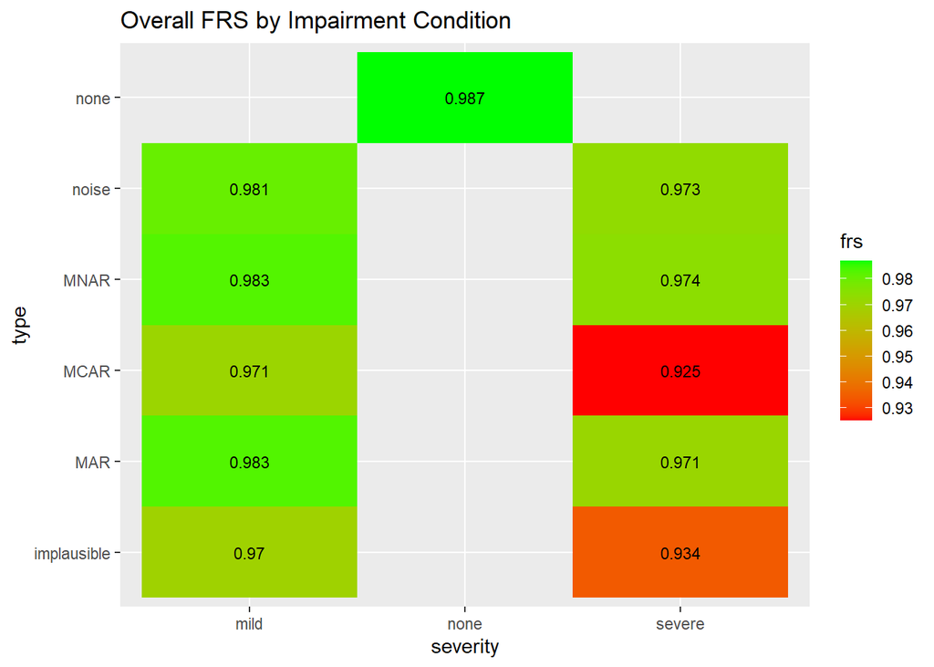

```r
# Heatmap: FRS by type x severity
ggplot(frs_summary$by_condition, aes(x = severity, y = type, fill = frs)) +
  geom_tile() +
  geom_text(aes(label = round(frs, 3)), size = 3) +
  scale_fill_gradient(low = "red", high = "green") +
  labs(title = "Overall FRS by Impairment Condition")
```

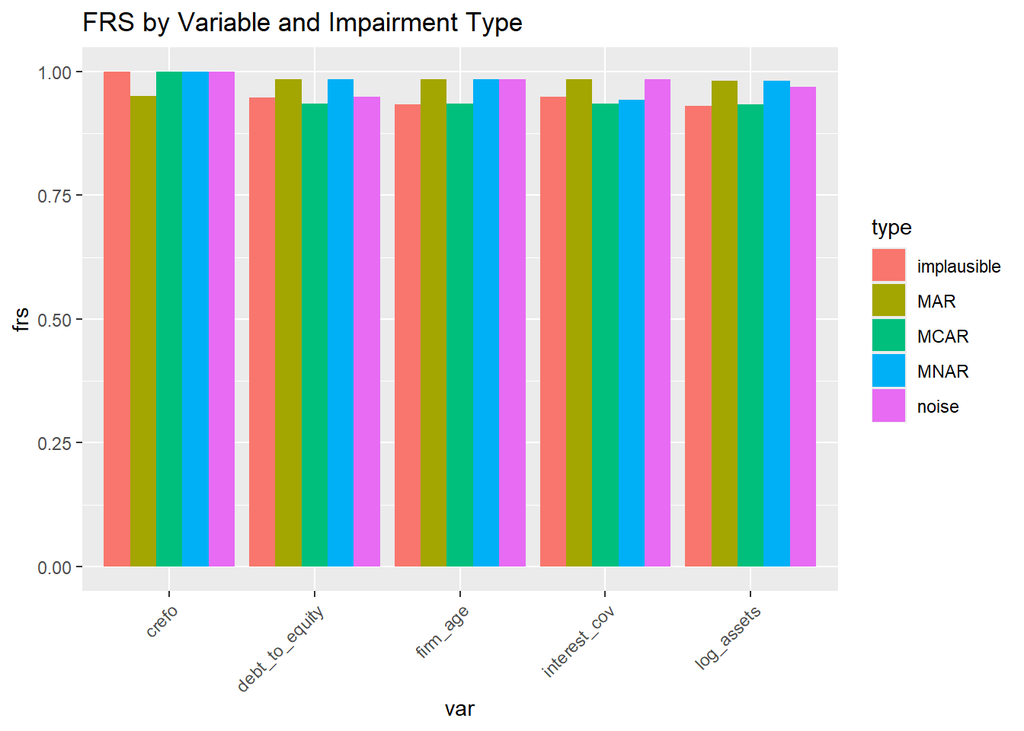

```r
# Bar chart: which variables degrade most per mechanism
ggplot(frs_summary$by_variable[frs_summary$by_variable$type != "none", ],
       aes(x = var, y = frs, fill = type)) +
  geom_col(position = "dodge") +
  labs(title = "FRS by Variable and Impairment Type") +
  theme(axis.text.x = element_text(angle = 45, hjust = 1))
```

Last step before modeling:

## **Stage 3: Data Preparation**

Preparation function: sits between impairment and model fitting. Handles the following tasks: 1. Identify extreme outliers and converts them to missings 2. Winsorize data (two or one tailed, depending on variables) 3. Impute NA values introduced by missingness 4. Recompute _z columns using clean scaling parameters

The method argument controls the imputation strategy: “ersatzwert” — RR univariate Ersatzwert imputation (default). For each variable independently: fits a univariate logistic regression (default ~ x) on non-missing cases, computes the observed default rate among missing cases (AR_MV), and solves for the x-value that would produce that default rate: Ersatzwert = (logit(AR_MV) - β₀) / β₁ All missing rows receive the same replacement value per variable. Implements the RR development-phase imputation methodology. “median” — univariate median imputation (PD-neutral baseline; maps to ~z=0 after standardisation, adding approximately zero to the linear predictor). “mice” — multivariate imputation by chained equations (van Buuren & Groothuis-Oudshoorn, 2011). Uses predictive mean matching (pmm) as the default method, which preserves the distribution shape and avoids impossible values. Single imputation (m=1) is used because Monte Carlo replications serve the role of repeated draws. Requires the mice package.

This function is applied identically regardless of the missingness mechanism (MCAR/MAR/MNAR), reflecting practitioner norms where the true mechanism is unknown and all missingness is treated the same.

Fixing the data with the practitioner default method of Ersatzwert imputation

```r
# ── Prepare all impaired datasets for modeling ─────────────────────────────

# Check domain boundaries, winsorize, impute NAs using the default Ersatzwert technique + recompute z-scores

dat_mcar_mild_prepped   <- prepare_for_modeling(dat_mcar_mild, result$scaling, method = "ersatzwert", model_formula = pd_formula)
```

```
## [MCAR mild] Data preparation:
##   Domain check: no impossible values found.
##   Winsorize log_assets: 5523 low (< 6.56), 5523 high (> 13.43)
##   Winsorize debt_to_equity: 11052 high (> 5.89)
##   Winsorize interest_cov: 11044 high (> 12.19)
##   Winsorize firm_age: 11046 high (> 44.56)
##   log_assets_z: 19224 NAs → Ersatzwert = -0.0191 (AR_MV = 0.0225)
##   debt_to_equity_z: 19083 NAs → Ersatzwert = 0.2172 (AR_MV = 0.0238)
##   interest_cov_z: 19253 NAs → Ersatzwert = -0.1717 (AR_MV = 0.0233)
##   firm_age_z: 19211 NAs → Ersatzwert = -0.0431 (AR_MV = 0.0242)
## [MCAR mild] RR univariate imputation complete | 76771 cells imputed
```

```r
dat_mcar_severe_prepped <- prepare_for_modeling(dat_mcar_severe, result$scaling, method = "ersatzwert", model_formula = pd_formula)
```

```
## [MCAR severe] Data preparation:
##   Domain check: no impossible values found.
##   Winsorize log_assets: 4322 low (< 6.56), 4322 high (> 13.43)
##   Winsorize debt_to_equity: 8652 high (> 5.89)
##   Winsorize interest_cov: 8638 high (> 12.21)
##   Winsorize firm_age: 8662 high (> 44.62)
##   log_assets_z: 67273 NAs → Ersatzwert = -0.1514 (AR_MV = 0.0241)
##   debt_to_equity_z: 67090 NAs → Ersatzwert = 0.1475 (AR_MV = 0.0231)
##   interest_cov_z: 67370 NAs → Ersatzwert = -0.2055 (AR_MV = 0.0238)
##   firm_age_z: 66885 NAs → Ersatzwert = 0.2707 (AR_MV = 0.0226)
## [MCAR severe] RR univariate imputation complete | 268618 cells imputed
```

```r
dat_mar_mild_prepped    <- prepare_for_modeling(dat_mar_mild, result$scaling, method = "ersatzwert", model_formula = pd_formula)
```

```
## [MAR mild] Data preparation:
##   Domain check: no impossible values found.
##   Winsorize log_assets: 6003 low (< 6.56), 6003 high (> 13.42)
##   Winsorize debt_to_equity: 12006 high (> 5.89)
##   Winsorize interest_cov: 12006 high (> 12.19)
##   Winsorize firm_age: 12006 high (> 44.61)
##   crefo_z: 18416 NAs → Ersatzwert = 0.5906 (AR_MV = 0.0266)
## [MAR mild] RR univariate imputation complete | 18416 cells imputed
```

```r
dat_mar_severe_prepped  <- prepare_for_modeling(dat_mar_severe, result$scaling, method = "ersatzwert", model_formula = pd_formula)
```

```
## [MAR severe] Data preparation:
##   Domain check: no impossible values found.
##   Winsorize log_assets: 6003 low (< 6.56), 6003 high (> 13.42)
##   Winsorize debt_to_equity: 12006 high (> 5.89)
##   Winsorize interest_cov: 12006 high (> 12.19)
##   Winsorize firm_age: 12006 high (> 44.61)
##   crefo_z: 67248 NAs → Ersatzwert = 0.5273 (AR_MV = 0.0248)
## [MAR severe] RR univariate imputation complete | 67248 cells imputed
```

```r
dat_mnar_mild_prepped   <- prepare_for_modeling(dat_mnar_mild, result$scaling, method = "ersatzwert", model_formula = pd_formula)
```

```
## [MNAR mild] Data preparation:
##   Domain check: no impossible values found.
##   Winsorize log_assets: 6003 low (< 6.56), 6003 high (> 13.42)
##   Winsorize debt_to_equity: 12006 high (> 5.89)
##   Winsorize interest_cov: 11092 high (> 12.35)
##   Winsorize firm_age: 12006 high (> 44.61)
##   interest_cov_z: 18293 NAs → Ersatzwert = -1.6895 (AR_MV = 0.0612)
## [MNAR mild] RR univariate imputation complete | 18293 cells imputed
```

```r
dat_mnar_severe_prepped <- prepare_for_modeling(dat_mnar_severe, result$scaling, method = "ersatzwert", model_formula = pd_formula)
```

```
## [MNAR severe] Data preparation:
##   Domain check: no impossible values found.
##   Winsorize log_assets: 6003 low (< 6.56), 6003 high (> 13.42)
##   Winsorize debt_to_equity: 12006 high (> 5.89)
##   Winsorize interest_cov: 9282 high (> 12.71)
##   Winsorize firm_age: 12006 high (> 44.61)
##   interest_cov_z: 54488 NAs → Ersatzwert = -1.4432 (AR_MV = 0.0465)
## [MNAR severe] RR univariate imputation complete | 54488 cells imputed
```

```r
dat_noise_mild_prepped   <- prepare_for_modeling(dat_noise_mild, result$scaling, method = "ersatzwert", model_formula = pd_formula)
```

```
## [noise mild] Data preparation:
##   Domain check: 13250 impossible debt_to_equity (< 0) → NA
##   Domain check: 55 impossible interest_cov (< 0) → NA
##   Winsorize log_assets: 6003 low (< 6.47), 6003 high (> 13.45)
##   Winsorize debt_to_equity: 11344 high (> 5.99)
##   Winsorize interest_cov: 12003 high (> 12.20)
##   Winsorize firm_age: 12006 high (> 44.61)
##   debt_to_equity_z: 13250 NAs → Ersatzwert = -7.3713 (AR_MV = 0.0002)
##   interest_cov_z: 55 NAs → Ersatzwert = -5.7722 (AR_MV = 0.5273)
## [noise mild] RR univariate imputation complete | 13305 cells imputed
```

```r
dat_noise_severe_prepped <- prepare_for_modeling(dat_noise_severe, result$scaling, method = "ersatzwert", model_formula = pd_formula)
```

```
## [noise severe] Data preparation:
##   Domain check: 14655 impossible debt_to_equity (< 0) → NA
##   Domain check: 422 impossible interest_cov (< 0) → NA
##   Winsorize log_assets: 6003 low (< 5.75), 6003 high (> 13.70)
##   Winsorize debt_to_equity: 11273 high (> 6.47)
##   Winsorize interest_cov: 11985 high (> 12.29)
##   Winsorize firm_age: 12006 high (> 44.61)
##   debt_to_equity_z: 14655 NAs → Ersatzwert = -7.2342 (AR_MV = 0.0008)
##   interest_cov_z: 422 NAs → Ersatzwert = -6.3855 (AR_MV = 0.2536)
## [noise severe] RR univariate imputation complete | 15077 cells imputed
```

```r
dat_impl_mild_prepped    <- prepare_for_modeling(dat_impl_mild, result$scaling, method = "ersatzwert", model_formula = pd_formula)
```

```
## [implausible mild] Data preparation:
##   Domain check: 4311 impossible log_assets (< 0) → NA
##   Domain check: 3538 impossible debt_to_equity (< 0) → NA
##   Domain check: 3701 impossible interest_cov (< 0) → NA
##   Domain check: 3686 impossible firm_age (<= 0) → NA
##   Winsorize log_assets: 5896 low (< 6.42), 5896 high (> 15.78)
##   Winsorize debt_to_equity: 11829 high (> 6.35)
##   Winsorize interest_cov: 11821 high (> 13.67)
##   Winsorize firm_age: 11822 high (> 55.31)
##   log_assets_z: 4311 NAs → Ersatzwert = 2.7521 (AR_MV = 0.0227)
##   debt_to_equity_z: 3538 NAs → Ersatzwert = -1.4476 (AR_MV = 0.0226)
##   interest_cov_z: 3701 NAs → Ersatzwert = 63.1519 (AR_MV = 0.0203)
##   firm_age_z: 3686 NAs → Ersatzwert = 0.1000 (AR_MV = 0.0233)
## [implausible mild] RR univariate imputation complete | 15236 cells imputed
```

```r
dat_impl_severe_prepped  <- prepare_for_modeling(dat_impl_severe, result$scaling, method = "ersatzwert", model_formula = pd_formula)
```

```
## [implausible severe] Data preparation:
##   Domain check: 13063 impossible log_assets (< 0) → NA
##   Domain check: 10865 impossible debt_to_equity (< 0) → NA
##   Domain check: 10714 impossible interest_cov (< 0) → NA
##   Domain check: 10703 impossible firm_age (<= 0) → NA
##   Winsorize log_assets: 5677 low (< 5.82), 5677 high (> 87.41)
##   Winsorize debt_to_equity: 11463 high (> 27.73)
##   Winsorize interest_cov: 11470 high (> 147.02)
##   Winsorize firm_age: 11471 high (> 569.18)
##   log_assets_z: 13063 NAs → Ersatzwert = -9.7910 (AR_MV = 0.0254)
##   debt_to_equity_z: 10865 NAs → Ersatzwert = 3.8693 (AR_MV = 0.0237)
##   interest_cov_z: 10714 NAs → Ersatzwert = 0.2913 (AR_MV = 0.0240)
##   firm_age_z: 10703 NAs → Ersatzwert = -0.1402 (AR_MV = 0.0249)
## [implausible severe] RR univariate imputation complete | 45345 cells imputed
```

Moving into a list for later:

```r
prep_ersatz_list <- list(
  mcar_mild    = dat_mcar_mild_prepped,
  mcar_severe  = dat_mcar_severe_prepped,
  mar_mild     = dat_mar_mild_prepped,
  mar_severe   = dat_mar_severe_prepped,
  mnar_mild    = dat_mnar_mild_prepped,
  mnar_severe  = dat_mnar_severe_prepped,
  noise_mild   = dat_noise_mild_prepped,
  noise_severe = dat_noise_severe_prepped,
  impl_mild    = dat_impl_mild_prepped,
  impl_severe  = dat_impl_severe_prepped
)
```

**Sidequest: what happens if we use median or mice?**

Sidequest 1: Imputation Test

```r
source("02_sidequest1_imputation_x_models.R")
```

```
## Preparing median imputation for: mcar_mild, mcar_severe, mar_mild, mar_severe, mnar_mild, mnar_severe, noise_mild, noise_severe, impl_mild, impl_severe
## [MCAR mild] Data preparation:
##   Domain check: no impossible values found.
##   Winsorize log_assets: 5523 low (< 6.56), 5523 high (> 13.43)
##   Winsorize debt_to_equity: 11052 high (> 5.89)
##   Winsorize interest_cov: 11044 high (> 12.19)
##   Winsorize firm_age: 11046 high (> 44.56)
## Median imputed 19224 NAs in log_assets           method: median, value: 8.8447
## Median imputed 19083 NAs in debt_to_equity       method: median, value: 3.5801
## Median imputed 19253 NAs in interest_cov         method: median, value: 5.2989
## Median imputed 19211 NAs in firm_age             method: median, value: 20.1813
## [MCAR severe] Data preparation:
##   Domain check: no impossible values found.
##   Winsorize log_assets: 4322 low (< 6.56), 4322 high (> 13.43)
##   Winsorize debt_to_equity: 8652 high (> 5.89)
##   Winsorize interest_cov: 8638 high (> 12.21)
##   Winsorize firm_age: 8662 high (> 44.62)
## Median imputed 67273 NAs in log_assets           method: median, value: 8.8434
## Median imputed 67090 NAs in debt_to_equity       method: median, value: 3.5827
## Median imputed 67370 NAs in interest_cov         method: median, value: 5.3010
## Median imputed 66885 NAs in firm_age             method: median, value: 20.1411
## [MAR mild] Data preparation:
##   Domain check: no impossible values found.
##   Winsorize log_assets: 6003 low (< 6.56), 6003 high (> 13.42)
##   Winsorize debt_to_equity: 12006 high (> 5.89)
##   Winsorize interest_cov: 12006 high (> 12.19)
##   Winsorize firm_age: 12006 high (> 44.61)
## Median imputed 18416 NAs in crefo                method: median, value: 320.0000
## [MAR severe] Data preparation:
##   Domain check: no impossible values found.
##   Winsorize log_assets: 6003 low (< 6.56), 6003 high (> 13.42)
##   Winsorize debt_to_equity: 12006 high (> 5.89)
##   Winsorize interest_cov: 12006 high (> 12.19)
##   Winsorize firm_age: 12006 high (> 44.61)
## Median imputed 67248 NAs in crefo                method: median, value: 319.0000
## [MNAR mild] Data preparation:
##   Domain check: no impossible values found.
##   Winsorize log_assets: 6003 low (< 6.56), 6003 high (> 13.42)
##   Winsorize debt_to_equity: 12006 high (> 5.89)
##   Winsorize interest_cov: 11092 high (> 12.35)
```

[output cut: 210 more lines]

```
##      method mean_abs_diff max_abs_diff
##  ersatzwert     0.2822915    0.9724877
##        mice     0.2899340    0.9716533
##      median     0.2908994    0.9725742
##
## === SQ1: Mean |beta - truth| by Term × Method ===
##            term ersatzwert     median      mice
##           crefo 0.21761998 0.22392123 0.2404131
##  debt_to_equity 0.13270768 0.13602763 0.1078680
##        firm_age 0.50918295 0.49398888 0.4658207
##       intercept 0.31414088 0.29865649 0.3189860
##    interest_cov 0.11153589 0.15745297 0.1306950
##      log_assets 0.07187846 0.07660208 0.0693937
##        sector_2 0.50537974 0.50412466 0.5039207
##        sector_3 0.39588623 0.43642140 0.4823751
```

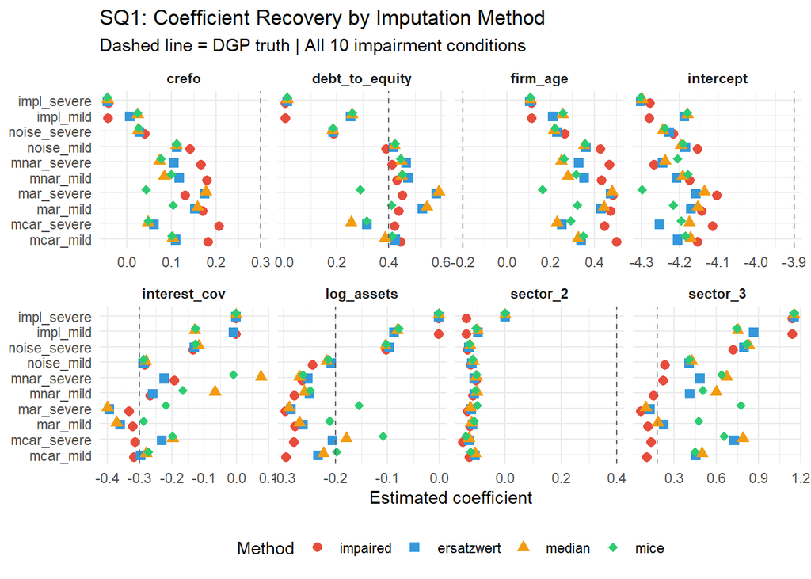

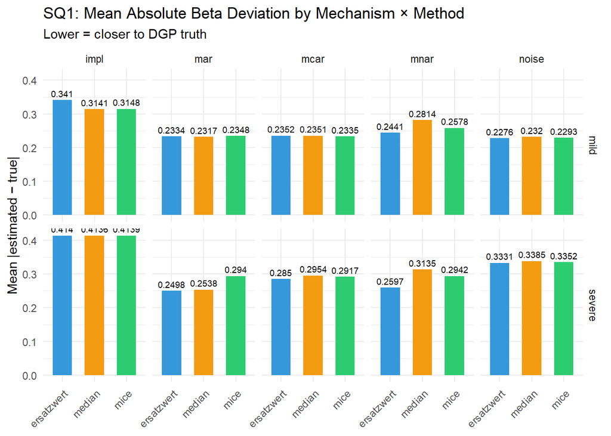

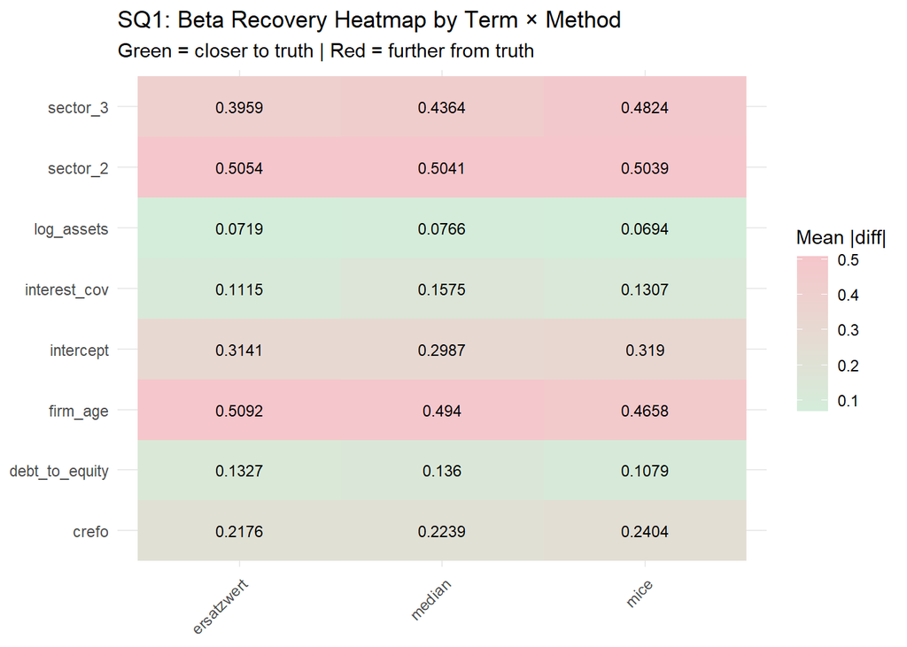

```
##
## === SQ1: MAR-Severe Beta Recovery (detailed) ===
##      method           term  true   estimated        diff   abs_diff
##  ersatzwert          crefo  0.30  0.17354416 -0.12645584 0.12645584
##      median          crefo  0.30  0.17672656 -0.12327344 0.12327344
##        mice          crefo  0.30  0.04302054 -0.25697946 0.25697946
##  ersatzwert debt_to_equity  0.40  0.58253068  0.18253068 0.18253068
##      median debt_to_equity  0.40  0.59103650  0.19103650 0.19103650
##        mice debt_to_equity  0.40  0.29012651 -0.10987349 0.10987349
##  ersatzwert       firm_age -0.20  0.47460358  0.67460358 0.67460358
##      median       firm_age -0.20  0.48134996  0.68134996 0.68134996
##        mice       firm_age -0.20  0.16317293  0.36317293 0.36317293
##  ersatzwert      intercept -3.90 -4.15723543 -0.25723543 0.25723543
##      median      intercept -3.90 -4.13607178 -0.23607178 0.23607178
##        mice      intercept -3.90 -4.29837482 -0.39837482 0.39837482
##  ersatzwert   interest_cov -0.30 -0.39494638 -0.09494638 0.09494638
##      median   interest_cov -0.30 -0.40026131 -0.10026131 0.10026131
##        mice   interest_cov -0.30 -0.21824336  0.08175664 0.08175664
##  ersatzwert     log_assets -0.20 -0.28647020 -0.08647020 0.08647020
##      median     log_assets -0.20 -0.29026738 -0.09026738 0.09026738
##        mice     log_assets -0.20 -0.15470362  0.04529638 0.04529638
##  ersatzwert       sector_2  0.40 -0.12302739 -0.52302739 0.52302739
##      median       sector_2  0.40 -0.12737802 -0.52737802 0.52737802
##        mice       sector_2  0.40 -0.10074729 -0.50074729 0.50074729
##  ersatzwert       sector_3  0.18  0.12662773 -0.05337227 0.05337227
##      median       sector_3  0.18  0.09924862 -0.08075138 0.08075138
##        mice       sector_3  0.18  0.77616945  0.59616945 0.59616945
##
## === SQ1: Implausible-Severe Beta Recovery (detailed) ===
##      method           term  true     estimated       diff  abs_diff
##  ersatzwert          crefo  0.30 -0.0427250895 -0.3427251 0.3427251
##      median          crefo  0.30 -0.0427623968 -0.3427624 0.3427624
##        mice          crefo  0.30 -0.0427271613 -0.3427272 0.3427272
##  ersatzwert debt_to_equity  0.40  0.0106680355 -0.3893320 0.3893320
##      median debt_to_equity  0.40  0.0105763486 -0.3894237 0.3894237
##        mice debt_to_equity  0.40  0.0111435879 -0.3888564 0.3888564
##  ersatzwert       firm_age -0.20  0.1070997239  0.3070997 0.3070997
##      median       firm_age -0.20  0.1070859601  0.3070860 0.3070860
##        mice       firm_age -0.20  0.1074330833  0.3074331 0.3074331
##  ersatzwert      intercept -3.90 -4.3019224316 -0.4019224 0.4019224
##      median      intercept -3.90 -4.2986981746 -0.3986982 0.3986982
##        mice      intercept -3.90 -4.3020270340 -0.4020270 0.4020270
##  ersatzwert   interest_cov -0.30 -0.0005480252  0.2994520 0.2994520
##      median   interest_cov -0.30 -0.0005470916  0.2994529 0.2994529
##        mice   interest_cov -0.30 -0.0004502332  0.2995498 0.2995498
##  ersatzwert     log_assets -0.20 -0.0014215453  0.1985785 0.1985785
##      median     log_assets -0.20 -0.0015014268  0.1984986 0.1984986
##        mice     log_assets -0.20 -0.0012731741  0.1987268 0.1987268
##  ersatzwert       sector_2  0.40 -0.0002937519 -0.4002938 0.4002938
##      median       sector_2  0.40 -0.0002920520 -0.4002921 0.4002921
##        mice       sector_2  0.40 -0.0000103755 -0.4000104 0.4000104
##  ersatzwert       sector_3  0.18  1.1524877415  0.9724877 0.9724877
##      median       sector_3  0.18  1.1525742073  0.9725742 0.9725742
##        mice       sector_3  0.18  1.1516533238  0.9716533 0.9716533
##
## ✓ SQ1 complete. Objects in environment:
##   sq1_coefs       — full coefficient recovery table with method labels
##   sq1_summary     — mean |deviation| by method × condition
##   sq1_overall     — overall method ranking
##   sq1_by_beta     — per-term breakdown by method
##   p1, p2, p3      — ggplot objects
```

```r
# Now median_full and mice_full exist with all 10 conditions
```

**Notes on Imputation Method**:

- Despite more computational power needed, not seeing a large benefit to using MICE over Ersatzwert or Median after looking at beta recovery

**Sidequest 2: can FRS pick up on data quality issues before modeling** Comparing FRS across imputation methods for missingness

```r
frs_compare <- compare_frs_imputation(
  dat, impaired_list, prep_ersatz_list,
  median_full, mice_full,
  result$winsor_bounds, result$plausibility_bounds
)
frs_compare
```

```
##     completeness plausibility   outlier consistency       frs            var
## 1      1.0000000    0.9799929 0.9499990   0.9990005 0.9820372     log_assets
## 2      1.0000000    0.9899965 0.9499990   0.9990005 0.9845338 debt_to_equity
## 3      1.0000000    0.9899965 0.9499990   0.9999917 0.9847779   interest_cov
## 4      1.0000000    0.9899965 0.9499990   1.0000000 0.9847799       firm_age
## 5      1.0000000    1.0000000 1.0000000   0.9978302 0.9994571          crefo
## 6      1.0000000    0.9899965 0.9599992   0.9991646 0.9871172           MEAN
## 7      0.9199384    0.9799584 0.9498938   0.9991462 0.9617620     log_assets
## 8      0.9205256    0.9900874 0.9500163   0.9991462 0.9644226 debt_to_equity
## 9      0.9198176    0.9900390 0.9500865   0.9999958 0.9644480   interest_cov
## 10     0.9199925    0.9899821 0.9502363   1.0000000 0.9645190       firm_age
## 11     1.0000000    1.0000000 1.0000000   0.9983175 0.9995791          crefo
## 12     0.9360548    0.9900134 0.9600466   0.9993212 0.9709462           MEAN
## 13     0.7198301    0.9801264 0.9499254   0.9995002 0.9046823     log_assets
## 14     0.7205922    0.9902442 0.9505100   0.9995002 0.9073877 debt_to_equity
```

[output cut: 479 more lines]

And visualizations

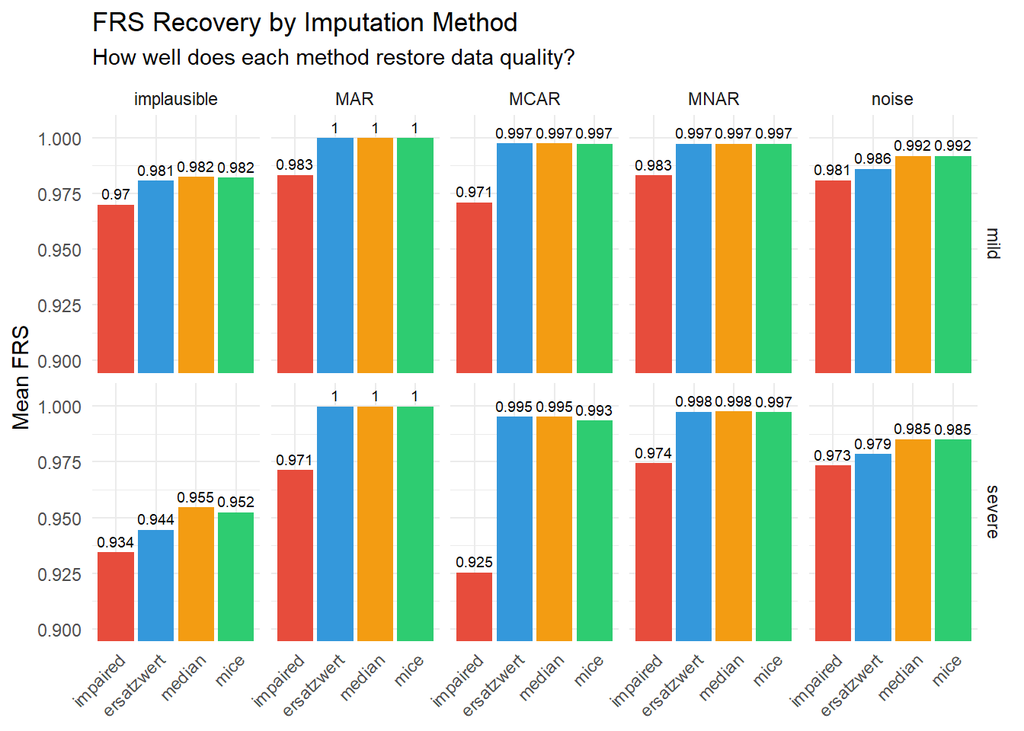

```r
# ---- Plot 1: Overall FRS by mechanism x severity x imputation method ------
# Collapse across variables first
frs_summary <- aggregate(
  frs ~ type + severity + stage,
  data = frs_compare[frs_compare$var != "MEAN" & frs_compare$type != "none", ],
  FUN  = mean
)

ggplot(frs_summary, aes(x = stage, y = frs, fill = stage)) +
  geom_col() +
  geom_text(aes(label = round(frs, 3)), vjust = -0.5, size = 2.5) +
  facet_grid(severity ~ type) +
  coord_cartesian(ylim = c(0.90, 1.005)) +
  scale_fill_manual(values = c(clean      = "grey70",
                               impaired   = "#e74c3c",
                               ersatzwert = "#3498db",
                               median     = "#f39c12",
                               mice       = "#2ecc71")) +
  labs(title    = "FRS Recovery by Imputation Method",
       subtitle = "How well does each method restore data quality?",
       y = "Mean FRS", x = NULL) +
  theme_minimal() +
  theme(legend.position = "none",
        axis.text.x = element_text(angle = 45, hjust = 1))
```

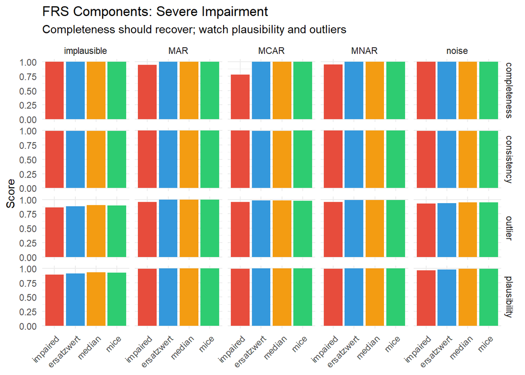

```r
# ---- Plot 2: Component breakdown for a deeper look -----------------------
# Pivot to long format for faceting by component
frs_long <- pivot_longer(
  frs_compare[frs_compare$var != "MEAN" & frs_compare$type != "none", ],
  cols      = c(completeness, plausibility, outlier, consistency),
  names_to  = "component",
  values_to = "score"
)

frs_comp_summary <- aggregate(
  score ~ type + severity + stage + component,
  data = frs_long,
  FUN  = mean
)

ggplot(frs_comp_summary[frs_comp_summary$severity == "severe", ],
       aes(x = stage, y = score, fill = stage)) +
  geom_col() +
  facet_grid(component ~ type) +
  scale_fill_manual(values = c(clean      = "grey70",
                               impaired   = "#e74c3c",
                               ersatzwert = "#3498db",
                               median     = "#f39c12",
                               mice       = "#2ecc71")) +
  labs(title    = "FRS Components: Severe Impairment",
       subtitle = "Completeness should recover; watch plausibility and outliers",
       y = "Score", x = NULL) +
  theme_minimal() +
  theme(legend.position = "none",
        axis.text.x = element_text(angle = 45, hjust = 1))
```

FRS visualizations per variable

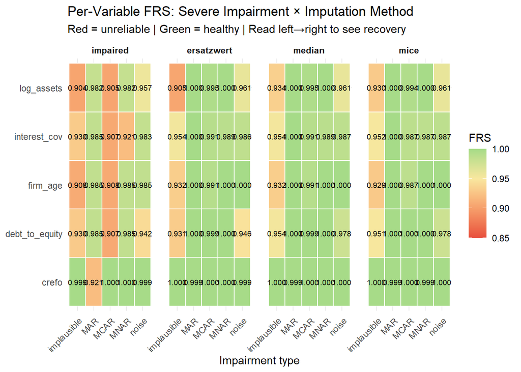

```r
# Filter to severe + drop the aggregate MEAN row
frs_var_severe <- frs_compare %>%
  filter(severity == "severe", var != "MEAN")

# Reshape: one column per stage for the heatmap facets
# frs_compare should already have columns: type, severity, var, stage, frs
# (plus the component columns)

ggplot(frs_var_severe,
       aes(x = type, y = var, fill = frs)) +
  geom_tile(color = "white", linewidth = 0.4) +
  geom_text(aes(label = sprintf("%.3f", frs)), size = 2.5) +
  facet_wrap(~ stage, nrow = 1) +
  scale_fill_gradient2(
    low = "#e74c3c", mid = "#f9e79f", high = "#2ecc71",
    midpoint = 0.95, limits = c(0.85, 1),
    oob = scales::squish,          # clamp anything outside range
    name = "FRS"
  ) +
  labs(
    title    = "Per-Variable FRS: Severe Impairment × Imputation Method",
    subtitle = "Red = unreliable | Green = healthy | Read left→right to see recovery",
    x = "Impairment type", y = NULL
  ) +
  theme_minimal() +
  theme(
    axis.text.x  = element_text(angle = 45, hjust = 1),
    strip.text    = element_text(face = "bold"),
    panel.spacing = unit(1, "lines")
  )
```

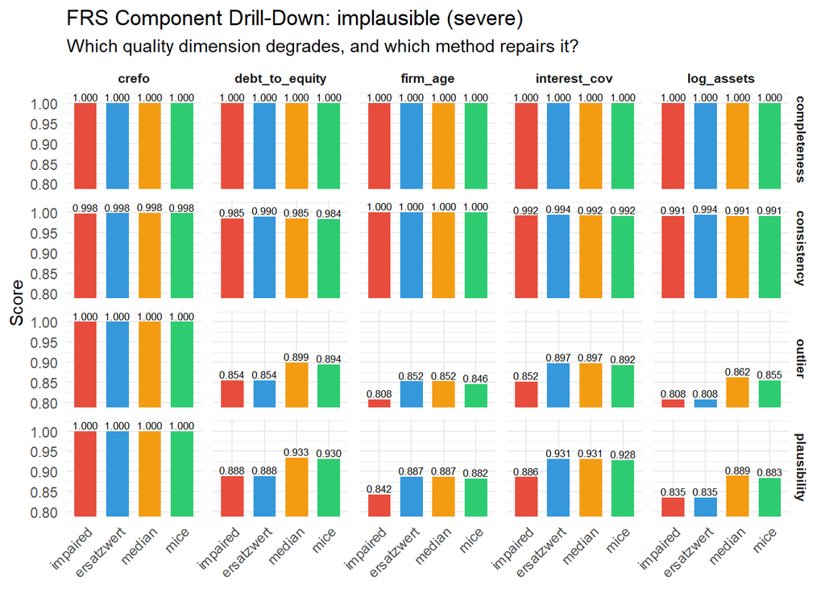

```r
# Pick whichever impairment type you want to drill into
focus_type <- "implausible"   # swap to "MNAR", "noise", etc.

frs_comp_var <- frs_compare %>%
  filter(severity == "severe", type == focus_type, var != "MEAN") %>%
  pivot_longer(
    cols      = c(completeness, plausibility, outlier, consistency),
    names_to  = "component",
    values_to = "score"
  )

frs_comp_var$stage <- factor(frs_comp_var$stage,
                             levels = c("impaired", "ersatzwert", "median", "mice"))

ggplot(frs_comp_var,
       aes(x = stage, y = score, fill = stage)) +
  geom_col(width = 0.7) +
  geom_text(aes(label = sprintf("%.3f", score)), vjust = -0.3, size = 2.2) +
  facet_grid(component ~ var) +
  coord_cartesian(ylim = c(0.80, 1.02)) +
  scale_fill_manual(values = c(impaired   = "#e74c3c",
                               ersatzwert = "#3498db",
                               median     = "#f39c12",
                               mice       = "#2ecc71")) +
  labs(
    title    = paste0("FRS Component Drill-Down: ", focus_type, " (severe)"),
    subtitle = "Which quality dimension degrades, and which method repairs it?",
    x = NULL, y = "Score"
  ) +
  theme_minimal() +
  theme(
    legend.position = "none",
    axis.text.x     = element_text(angle = 45, hjust = 1),
    strip.text       = element_text(face = "bold", size = 8),
    panel.spacing    = unit(0.5, "lines")
  )
```

# **Stage 4: Modeling**

## 4a Logistic Regression

### Overview

The logistic regression is the workhorse model for PD estimation in regulatory credit risk (EBA GL 2017/16). RR uses `glm()` with `family = binomial()` – the standard maximum-likelihood logit.

The function fits the same formula across three stages:

1. **Clean** – the baseline, best-case coefficient recovery
2. **Impaired** – damage applied, no preparation. How bad does it get?
3. **Prepared** – after winsorizing, imputation, and rescaling. Did preparation recover anything?

For the missingness conditions (MCAR, MAR, MNAR), the raw impaired datasets contain NAs. `glm()` handles this via complete-case analysis – it silently drops any row with a missing value in a predictor. This is informative: it shows what the model can recover when it simply discards incomplete observations, and it provides a natural comparison point for the prepared version where imputation fills those gaps. For noise and implausible conditions, there are no NAs, so the raw fit runs on the full distorted data with no cleanup.

Each fit stores:

- **The fitted model object** (for later prediction, diagnostics, etc.)
- **Estimated coefficients** alongside the true betas, with absolute differences – this is the coefficient recovery check
- **Number of observations used** – important for interpreting the complete-case fits where glm drops NA rows
- **Convergence flag** – glm can occasionally fail to converge on heavily impaired data; we want to know when that happens rather than silently carrying a bad fit forward

Running it on all conditions – raw impaired data (impaired_list) and ersatzwert-imputed prepared data (prep_ersatz_list):

```r
glm_results <- fit_logistic_models(
  clean_data    = dat,
  impaired_list = impaired_list,
  prepared_list = prep_ersatz_list,
  formula       = pd_formula,
  true_betas    = result$true_betas
)

# Quick look: coefficient recovery across all conditions
print(glm_results$coef_recovery)
```

```
##                   key    stage    condition           term  true     estimated
## 1               clean    clean        clean      intercept -3.90 -4.1379444006
## 2               clean    clean        clean     log_assets -0.20 -0.2879958758
## 3               clean    clean        clean debt_to_equity  0.40  0.4407361327
## 4               clean    clean        clean   interest_cov -0.30 -0.3261118155
## 5               clean    clean        clean       sector_2  0.40 -0.1195566873
## 6               clean    clean        clean       sector_3  0.18  0.1044599949
## 7               clean    clean        clean       firm_age -0.20  0.4701493134
## 8               clean    clean        clean          crefo  0.30  0.1702713302
## 9       imp_mcar_mild impaired    mcar_mild      intercept -3.90 -4.1534672581
## 10      imp_mcar_mild impaired    mcar_mild     log_assets -0.20 -0.2952164441
## 11      imp_mcar_mild impaired    mcar_mild debt_to_equity  0.40  0.4447485570
## 12      imp_mcar_mild impaired    mcar_mild   interest_cov -0.30 -0.3186567914
## 13      imp_mcar_mild impaired    mcar_mild       sector_2  0.40 -0.1300989587
## 14      imp_mcar_mild impaired    mcar_mild       sector_3  0.18  0.1092624466
```

[output cut: 323 more lines]

### Coefficient recovery: how far did the betas drift?

A first visual diagnostic: for each impairment condition, how close are the recovered coefficients to the DGP truth? Three stages are shown side-by-side: the clean baseline (triangle), raw impaired fits (circle), and prepared fits (square). The question at each panel is: does the square move back toward the dashed truth line compared to the circle?

Note on sample sizes: for MCAR/MAR/MNAR impaired fits, glm performs complete-case analysis (dropping rows with any NA). This means the impaired models for missingness conditions train on fewer observations than the prepared versions where imputation restores completeness. The n_obs column in coef_recovery tracks this.

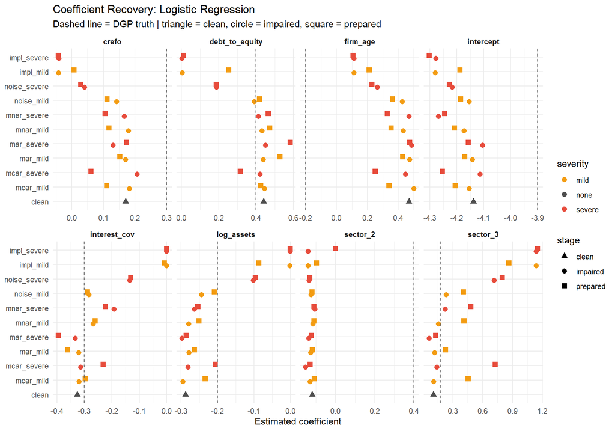

```r
# ── Coefficient recovery dot plot: three-stage comparison ──────────────

# Readable ordering for the y-axis
condition_order <- c("clean",
                     "mcar_mild", "mcar_severe",
                     "mar_mild",  "mar_severe",
                     "mnar_mild", "mnar_severe",
                     "noise_mild", "noise_severe",
                     "impl_mild", "impl_severe")

glm_results$coef_recovery$condition <- factor(
  glm_results$coef_recovery$condition,
  levels = condition_order
)

glm_results$coef_recovery$stage <- factor(
  glm_results$coef_recovery$stage,
  levels = c("clean", "impaired", "prepared")
)

ggplot(glm_results$coef_recovery,
       aes(x = estimated, y = condition, color = severity, shape = stage)) +
  geom_point(size = 2.5, position = position_dodge(width = 0.4)) +
  geom_vline(aes(xintercept = true), linetype = "dashed", color = "grey40") +
  facet_wrap(~ term, scales = "free_x", ncol = 4) +
  scale_color_manual(values = c(none = "grey30", mild = "#f39c12", severe = "#e74c3c")) +
  scale_shape_manual(values = c(clean = 17, impaired = 16, prepared = 15)) +
  labs(title    = "Coefficient Recovery: Logistic Regression",
       subtitle = "Dashed line = DGP truth | triangle = clean, circle = impaired, square = prepared",
       x = "Estimated coefficient", y = NULL) +
  theme_minimal() +
  theme(strip.text = element_text(face = "bold"))
```

## 4b XGBoost

### Overview

XGBoost is the second model in the simulation grid. Where logistic regression gives us interpretable coefficients to check against the DGP truth, XGBoost tests whether a flexible, non-parametric learner is more or less robust to data quality impairment.

Key structural differences from glm that matter here:

- **No formula interface.** XGBoost needs a numeric matrix (`xgb.DMatrix`) and a separate label vector. We extract the same predictor columns used in `pd_formula` and convert manually.
- **Native NA handling.** XGBoost learns optimal split directions for missing values during training. This means the raw impaired fits (stage = “impaired”) use *all* rows, including those with NAs – unlike glm, which drops them via complete-case analysis. This is a structurally different response to the same damage and part of the model comparison story
- **No coefficients.** XGBoost produces feature importance (gain-based) rather than interpretable betas. We store importance tables instead of coefficient recovery, and the real model comparison happens downstream at the evaluation stage (predicted PDs, discrimination, calibration, grading).
- **Fixed hyperparameters.** Since the research question is about data quality, not model tuning, we fix hyperparameters across all conditions. Any performance difference is then attributable to the data, not to tuning. The defaults below are conservative and standard for binary credit risk: shallow trees, moderate learning rate, early stopping to avoid overfitting.

Running it:

```r
xgb_results <- fit_xgboost_models(
  clean_data    = dat,
  impaired_list = impaired_list,
  prepared_list = prep_ersatz_list,
  formula       = pd_formula
)

# Quick look at feature importance across conditions
print(xgb_results$importance)
```

```
##              Feature               key    stage    condition        Gain
## 1            crefo_z             clean    clean        clean 0.514293404
## 2   debt_to_equity_z             clean    clean        clean 0.205530330
## 3         firm_age_z             clean    clean        clean 0.058272788
## 4     interest_cov_z             clean    clean        clean 0.127386459
## 5       log_assets_z             clean    clean        clean 0.080945165
## 6           sector_2             clean    clean        clean 0.011005221
## 7           sector_3             clean    clean        clean 0.002566633
## 8            crefo_z     imp_mcar_mild impaired    mcar_mild 0.521757326
## 9   debt_to_equity_z     imp_mcar_mild impaired    mcar_mild 0.205512883
## 10        firm_age_z     imp_mcar_mild impaired    mcar_mild 0.059468828
## 11    interest_cov_z     imp_mcar_mild impaired    mcar_mild 0.119291437
## 12      log_assets_z     imp_mcar_mild impaired    mcar_mild 0.081448822
## 13          sector_2     imp_mcar_mild impaired    mcar_mild 0.009422531
## 14          sector_3     imp_mcar_mild impaired    mcar_mild 0.003098172
```

[output cut: 281 more lines]

### Feature importance: does impairment reshuffle what the model relies on?

In the clean-data fit, XGBoost should allocate gain roughly in line with the true effect sizes in the DGP. Impairment can distort this in two ways: a damaged variable loses signal and drops in importance, or preparation artifacts (e.g., imputed values clustering at the median) make a variable artificially easy to split on.

The plot below shows gain-based importance by feature, comparing clean, impaired, and prepared stages across all conditions.

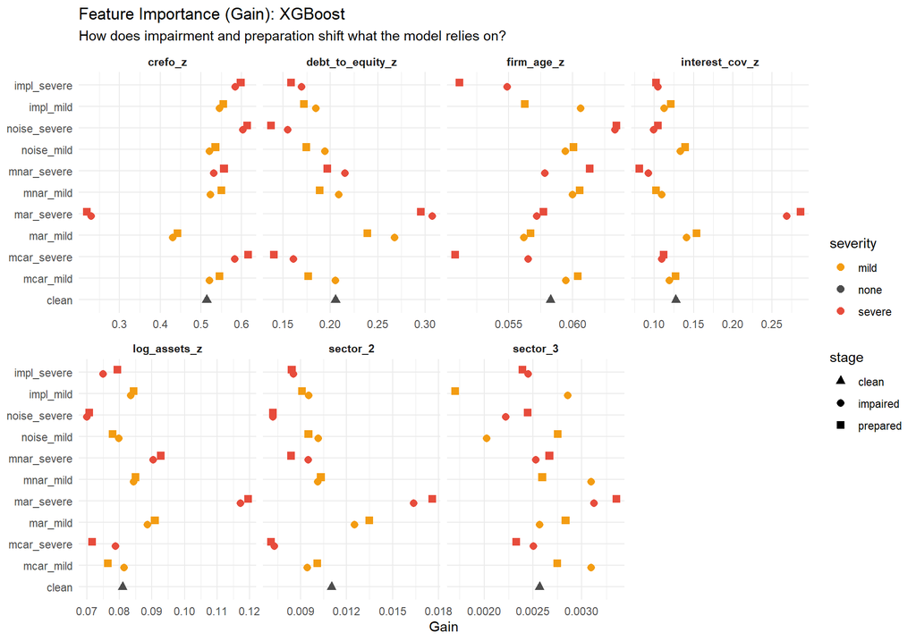

```r
# ── Feature importance comparison ──────────────────────────────────────

condition_order <- c("clean",
                     "mcar_mild", "mcar_severe",
                     "mar_mild",  "mar_severe",
                     "mnar_mild", "mnar_severe",
                     "noise_mild", "noise_severe",
                     "impl_mild", "impl_severe")

xgb_results$importance$condition <- factor(
  xgb_results$importance$condition,
  levels = condition_order
)

xgb_results$importance$stage <- factor(
  xgb_results$importance$stage,
  levels = c("clean", "impaired", "prepared")
)

ggplot(xgb_results$importance,
       aes(x = Gain, y = condition, color = severity, shape = stage)) +
  geom_point(size = 2.5, position = position_dodge(width = 0.4)) +
  facet_wrap(~ Feature, scales = "free_x", ncol = 4) +
  scale_color_manual(values = c(none = "grey30", mild = "#f39c12", severe = "#e74c3c")) +
  scale_shape_manual(values = c(clean = 17, impaired = 16, prepared = 15)) +
  labs(title    = "Feature Importance (Gain): XGBoost",
       subtitle = "How does impairment and preparation shift what the model relies on?",
       x = "Gain", y = NULL) +
  theme_minimal() +
  theme(strip.text = element_text(face = "bold"))
```

## 4c PD Grading

### Overview

After fitting models, the next step in a real-world PD framework is to assign each firm to a risk grade. This maps continuous predicted PDs onto a discrete rating scale, like how Moody’s maps default probabilities to letter grades (Aaa through C).

We use a 10-grade scale (1 = safest, 10 = riskiest) with PD boundaries derived from Moody’s one-year idealized corporate default rates. The mapping is:

| Grade | Moody’s Equivalent | PD Upper Bound |
| --- | --- | --- |
| 1 | Aaa | 0.001% |
| 2 | Aa | 0.06% |
| 3 | A | 0.11% |
| 4 | Baa | 0.30% |
| 5 | Ba (upper) | 0.70% |
| 6 | Ba (lower) | 1.50% |
| 7 | B (upper) | 3.00% |
| 8 | B (lower) | 8.00% |
| 9 | Caa | 15.00% |
| 10 | Ca-C / Default | 100.00% |

Given the DGP’s ~2% average default rate, most firms should cluster in grades 5-8, with relatively few in the tails. This is realistic for a B2B/SME portfolio.

The critical design choice: **bucket boundaries are fixed and model- independent.** The same PD thresholds are applied to all conditions, all stages, and both model types. This means a “grade 6” carries the same PD interpretation everywhere, and any shift in grade distributions across conditions is attributable to the model + data, not to a moving scale.

This also enables **grade migration analysis**: comparing which grade each firm receives under clean vs. impaired vs. prepared conditions. A firm graded 5 on clean data but 7 on impaired data has been misclassified by the damage – and whether preparation pulls it back toward 5 is the key question.

Running it for both models – note that we need to pass matched lists of models and datasets so that each model scores its own training data:

```r
# Build matched dataset lists (same structure as the model keys)
all_datasets <- c(
  list(clean = dat),
  setNames(
    lapply(names(impaired_list), function(nm) impaired_list[[nm]]),
    paste0("imp_", names(impaired_list))
  ),
  setNames(
    lapply(names(prep_ersatz_list), function(nm) prep_ersatz_list[[nm]]),
    paste0("prep_", names(prep_ersatz_list))
  )
)

# Grade all models
glm_grades <- assign_pd_grades(
  models     = glm_results$models,
  datasets   = all_datasets,
  formula    = pd_formula,
  model_type = "glm"
)

xgb_grades <- assign_pd_grades(
  models     = xgb_results$models,
  datasets   = all_datasets,
  formula    = pd_formula,
  model_type = "xgboost"
)
```

### Grade distributions: how does impairment shift the rating landscape?

The grade distribution under clean data is the “true” portfolio profile. Impairment should distort this – damaged data may push firms into the wrong grade, either overstating risk (conservative bias) or understating it (dangerous). The question at each panel is: does preparation restore the clean-data distribution?

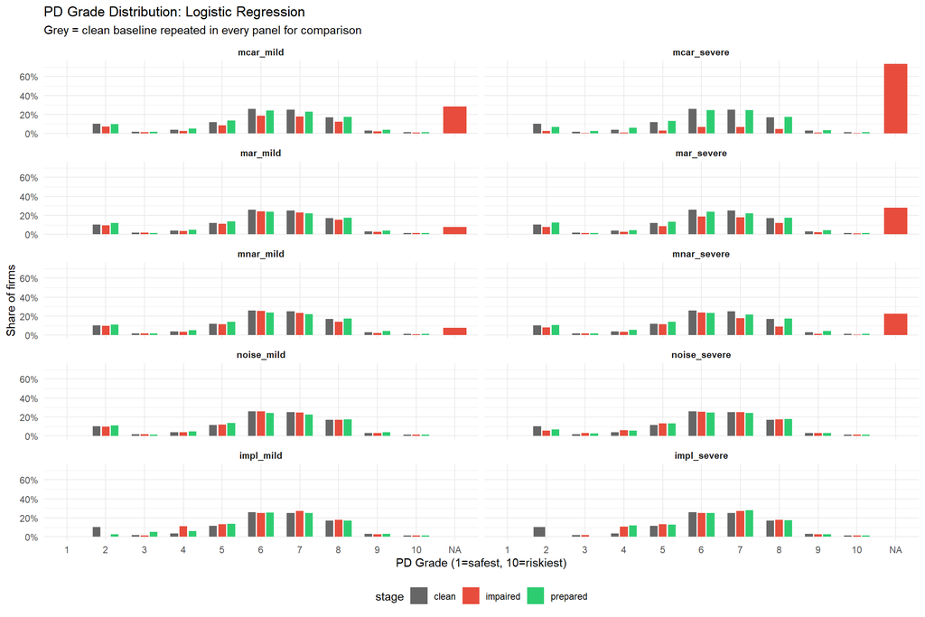

```r
# ── Grade distribution comparison: GLM ─────────────────────────────────

condition_order <- c("mcar_mild", "mcar_severe",
                     "mar_mild",  "mar_severe",
                     "mnar_mild", "mnar_severe",
                     "noise_mild", "noise_severe",
                     "impl_mild", "impl_severe")

# Get the clean distribution once
clean_dist <- glm_grades %>%
  filter(condition == "clean") %>%
  group_by(grade) %>%
  summarise(n = n(), .groups = "drop") %>%
  mutate(pct = n / sum(n),
         stage = "clean")

# Replicate clean distribution into every impaired condition
clean_repeated <- do.call(rbind, lapply(condition_order, function(cond) {
  clean_dist %>% mutate(condition = cond)
}))

# Compute impaired + prepared distributions (excluding the clean panel)
impaired_dist <- glm_grades %>%
  filter(condition != "clean") %>%
  group_by(condition, stage, grade) %>%
  summarise(n = n(), .groups = "drop") %>%
  group_by(condition, stage) %>%
  mutate(pct = n / sum(n)) %>%
  ungroup()

# Combine
glm_grade_dist           <- bind_rows(clean_repeated, impaired_dist)
glm_grade_dist$condition <- factor(glm_grade_dist$condition, levels = condition_order)
glm_grade_dist$stage     <- factor(glm_grade_dist$stage, levels = c("clean", "impaired", "prepared"))

ggplot(glm_grade_dist,
       aes(x = factor(grade), y = pct, fill = stage)) +
  geom_col(position = position_dodge(width = 0.7), width = 0.6) +
  facet_wrap(~ condition, ncol = 2) +
  scale_fill_manual(values = c(clean = "grey40", impaired = "#e74c3c", prepared = "#2ecc71")) +
  scale_y_continuous(labels = scales::percent_format()) +
  labs(title    = "PD Grade Distribution: Logistic Regression",
       subtitle = "Grey = clean baseline repeated in every panel for comparison",
       x = "PD Grade (1=safest, 10=riskiest)", y = "Share of firms") +
  theme_minimal() +
  theme(strip.text = element_text(face = "bold"),
        legend.position = "bottom")
```

```r
#
```

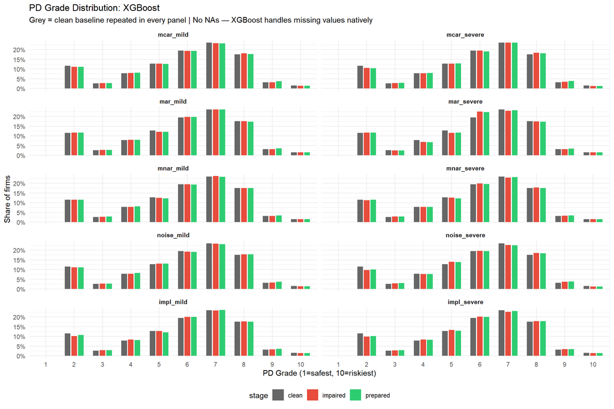

```r
# ── Grade distribution comparison: XGBoost ─────────────────────────────

condition_order <- c("mcar_mild", "mcar_severe",
                     "mar_mild",  "mar_severe",
                     "mnar_mild", "mnar_severe",
                     "noise_mild", "noise_severe",
                     "impl_mild", "impl_severe")

# Get the clean distribution once
clean_dist_xgb <- xgb_grades %>%
  filter(condition == "clean") %>%
  group_by(grade) %>%
  summarise(n = n(), .groups = "drop") %>%
  mutate(pct = n / sum(n),
         stage = "clean")

# Replicate clean distribution into every impaired condition
clean_repeated_xgb <- do.call(rbind, lapply(condition_order, function(cond) {
  clean_dist_xgb %>% mutate(condition = cond)
}))

# Compute impaired + prepared distributions (excluding the clean panel)
impaired_dist_xgb <- xgb_grades %>%
  filter(condition != "clean") %>%
  group_by(condition, stage, grade) %>%
  summarise(n = n(), .groups = "drop") %>%
  group_by(condition, stage) %>%
  mutate(pct = n / sum(n)) %>%
  ungroup()

# Combine
xgb_grade_dist <- bind_rows(clean_repeated_xgb, impaired_dist_xgb)
xgb_grade_dist$condition <- factor(xgb_grade_dist$condition, levels = condition_order)
xgb_grade_dist$stage     <- factor(xgb_grade_dist$stage, levels = c("clean", "impaired", "prepared"))

ggplot(xgb_grade_dist,
       aes(x = factor(grade), y = pct, fill = stage)) +
  geom_col(position = position_dodge(width = 0.7), width = 0.6) +
  facet_wrap(~ condition, ncol = 2) +
  scale_fill_manual(values = c(clean = "grey40", impaired = "#e74c3c", prepared = "#2ecc71")) +
  scale_y_continuous(labels = scales::percent_format()) +
  labs(title    = "PD Grade Distribution: XGBoost",
       subtitle = "Grey = clean baseline repeated in every panel | No NAs — XGBoost handles missing values natively",
       x = "PD Grade (1=safest, 10=riskiest)", y = "Share of firms") +
  theme_minimal() +
  theme(strip.text = element_text(face = "bold"),
        legend.position = "bottom")
```

# **Stage 5: Evaluation Metrics**

## Overview

The evaluation stage asks: how much does each impairment condition degrade model performance, and does preparation recover it? Following the RR model validation framework, we measure two of the three pillars: **discrimination** (can the model rank-order firms by risk?) and **calibration** (do predicted PDs match observed default frequencies?).

(The third pillar — stability (temporal drift, population stability) — is outside scope. Although the simulation generates a longitudinal panel spanning 2005–2025, the research question concerns data quality effects on model reliability rather than temporal model degradation. Stability testing would require a dedicated development/validation time split, which is orthogonal to the Monte Carlo design and left for future work.)

**Evaluation design.** Every model – clean-trained, impaired-trained, prepared-trained – predicts on the **same clean dataset**. This is the critical design choice: the clean data is the true risk surface (known from the DGP), and scoring every model against it isolates the effect of training-data damage on model performance. The clean-trained model’s metrics are the best-case ceiling; degradation from that ceiling is what we report.

Because the research question concerns relative degradation rather than out-of-sample prediction, all models are evaluated on the full clean dataset. The clean-trained model’s in-sample metrics serve as the upper bound. The Monte Carlo layer (Stage 6) provides the replication and sampling variability that a train/test split would otherwise supply.

**Metrics computed:**

- **AUC** (Area Under the ROC Curve): probability that a randomly chosen defaulter receives a higher predicted PD than a randomly chosen non-defaulter. Computed via the Mann-Whitney U statistic – no external package needed.
- **Gini coefficient**: `2 × AUC - 1`. Linearly equivalent to AUC but the standard reporting metric in regulatory credit risk (EBA GL 2017/16 uses AR/Gini for discriminatory power assessment).
- **KS statistic** (Kolmogorov-Smirnov): maximum vertical distance between the CDF of predicted PDs for defaulters vs. non-defaulters. Captures separation at the single point of maximum divergence, which AUC (averaging over the whole curve) can miss.
- **Brier score**: `mean((predicted - actual)²)`. A proper scoring rule that jointly captures discrimination and calibration. Lower is better.
- **O/E ratio** (Observed / Expected): observed default rate divided by mean predicted PD. A value of 1.0 indicates perfect aggregate calibration; below 1.0 means the model overpredicts default risk; above 1.0 means underprediction. This is the simplest regulatory calibration check.

**Main focus: Gini Coefficient (discrimination), O/E (overall calibration), secondarily Brier Score (discrimination + calibration)**

Running it for both models – every model scores on the same clean data:

```r
glm_metrics <- evaluate_models(
  models     = glm_results$models,
  eval_data  = dat,
  formula    = pd_formula,
  model_type = "glm"
)

xgb_metrics <- evaluate_models(
  models     = xgb_results$models,
  eval_data  = dat,
  formula    = pd_formula,
  model_type = "xgboost"
)

# Combine into one table for comparison
all_metrics <- rbind(glm_metrics, xgb_metrics)

print(all_metrics[, c("model_type", "condition", "stage",
                       "auc", "gini", "ks", "brier", "oe_ratio")])
```

```
##    model_type    condition    stage       auc      gini        ks      brier
## 1         glm        clean    clean 0.8012125 0.6024250 0.4363089 0.02147397
## 2         glm    mcar_mild impaired 0.8012753 0.6025506 0.4360376 0.02147846
## 3         glm  mcar_severe impaired 0.8014910 0.6029819 0.4382655 0.02148560
## 4         glm     mar_mild impaired 0.8013987 0.6027974 0.4371377 0.02147832
## 5         glm   mar_severe impaired 0.8006039 0.6012077 0.4344917 0.02146683
## 6         glm    mnar_mild impaired 0.8019011 0.6038023 0.4375363 0.02149667
## 7         glm  mnar_severe impaired 0.8022836 0.6045673 0.4374751 0.02156673
## 8         glm   noise_mild impaired 0.8026724 0.6053449 0.4390672 0.02151032
## 9         glm noise_severe impaired 0.8031706 0.6063412 0.4421617 0.02176172
## 10        glm    impl_mild impaired 0.7936259 0.5872519 0.4322354 0.02216356
## 11        glm  impl_severe impaired 0.7935293 0.5870585 0.4320362 0.02216624
## 12        glm    mcar_mild prepared 0.8035009 0.6070018 0.4387868 0.02184317
## 13        glm  mcar_severe prepared 0.8038973 0.6077947 0.4421545 0.02203010
## 14        glm     mar_mild prepared 0.8019454 0.6038908 0.4360691 0.02182250
```

[output cut: 71 more lines]

### Discrimination: how much ranking power does each model lose?

The primary question: when a model is trained on damaged data, how much worse does it rank-order firms by risk? AUC and Gini capture this directly. The clean-trained model sets the ceiling; any drop in the impaired or prepared rows is degradation caused by the data quality problem.

The plot below shows Gini (more common in credit risk reporting than AUC) by condition and stage. The clean baseline appears as a horizontal reference line in every panel.

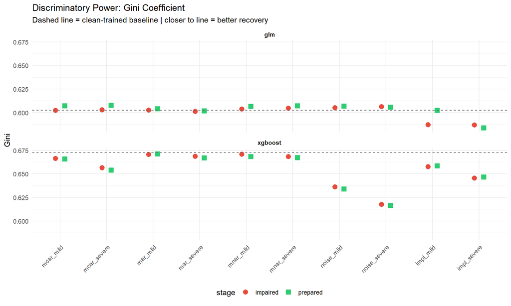

```r
# ── Gini degradation plot ──────────────────────────────────────────────

condition_order <- c("mcar_mild", "mcar_severe",
                     "mar_mild",  "mar_severe",
                     "mnar_mild", "mnar_severe",
                     "noise_mild", "noise_severe",
                     "impl_mild", "impl_severe")

plot_metrics <- all_metrics[all_metrics$condition != "clean", ]
plot_metrics$condition <- factor(plot_metrics$condition, levels = condition_order)
plot_metrics$stage     <- factor(plot_metrics$stage, levels = c("impaired", "prepared"))

# Clean baselines for reference lines (one per model type)
clean_gini <- all_metrics[all_metrics$condition == "clean",
                          c("model_type", "gini")]

ggplot(plot_metrics, aes(x = condition, y = gini,
                         color = stage, shape = stage)) +
  geom_point(size = 3, position = position_dodge(width = 0.4)) +
  geom_hline(data = clean_gini,
             aes(yintercept = gini),
             linetype = "dashed", color = "grey40") +
  facet_wrap(~ model_type, ncol = 1) +
  scale_color_manual(values = c(impaired = "#e74c3c", prepared = "#2ecc71")) +
  scale_shape_manual(values = c(impaired = 16, prepared = 15)) +
  labs(title    = "Discriminatory Power: Gini Coefficient",
       subtitle = "Dashed line = clean-trained baseline | closer to line = better recovery",
       x = NULL, y = "Gini") +
  theme_minimal() +
  theme(axis.text.x = element_text(angle = 45, hjust = 1),
        strip.text  = element_text(face = "bold"),
        legend.position = "bottom")
```

### Calibration: do predicted PDs still match reality?

The O/E ratio measures aggregate calibration – is the average predicted PD close to the observed default rate? Since every model predicts on the same clean data (where the true default rate is fixed), any shift in O/E away from the clean baseline means the model’s probability estimates have been distorted by impairment.

The Brier score combines calibration and discrimination into a single proper scoring rule. A model that ranks firms well but assigns the wrong PD levels will have a good AUC but a poor Brier score; the gap between the two tells you whether the problem is discrimination or calibration.

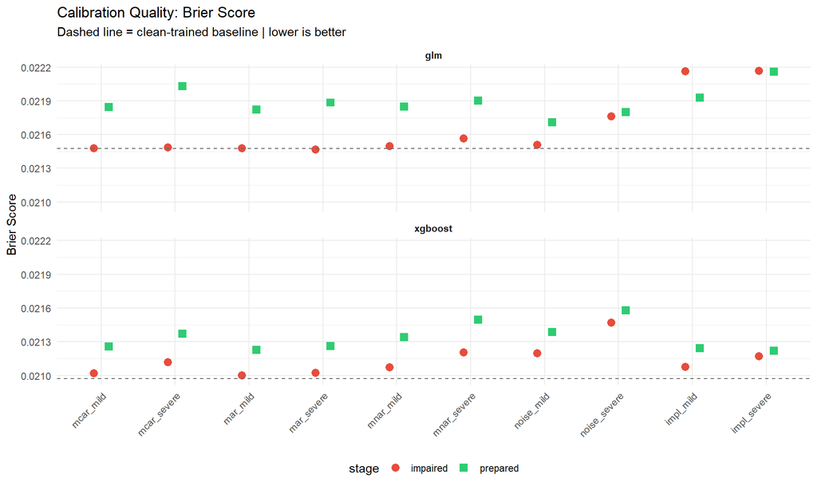

```r
# ── Brier score degradation plot ───────────────────────────────────────

clean_brier <- all_metrics[all_metrics$condition == "clean",
                           c("model_type", "brier")]

ggplot(plot_metrics, aes(x = condition, y = brier,
                         color = stage, shape = stage)) +
  geom_point(size = 3, position = position_dodge(width = 0.4)) +
  geom_hline(data = clean_brier,
             aes(yintercept = brier),
             linetype = "dashed", color = "grey40") +
  facet_wrap(~ model_type, ncol = 1) +
  scale_color_manual(values = c(impaired = "#e74c3c", prepared = "#2ecc71")) +
  scale_shape_manual(values = c(impaired = 16, prepared = 15)) +
  labs(title    = "Calibration Quality: Brier Score",
       subtitle = "Dashed line = clean-trained baseline | lower is better",
       x = NULL, y = "Brier Score") +
  theme_minimal() +
  theme(axis.text.x = element_text(angle = 45, hjust = 1),
        strip.text  = element_text(face = "bold"),
        legend.position = "bottom")
```

**Brier score** (composite, discrimination + calibration combined)

```
• XGBoost again has the better clean baseline. Starts lower and stays lower.
• Preparation hurts Brier score. Prepared data has the "mass point" issue that shrinks the variance, then GLM overcompensates / higher predicted PDs than expected. For XGB: mass point downgrades its information set. Replaces a better mechanism with a less-precise one
    ○ Therefore it's almost always higher than the impaired data in all cases)
    ○ XGBoost NA handling for MCAR / MNAR severe,noise also distorts the trees.
• GLM complete-case analysis holds calibration well until noise severe and implausible conditions, where it jumps sharply.  Impl Mild and Severe stay at the same level.
• MAR is the most stable condition for both models, consistent with the mechanism (missingness on crefo is independent of default risk conditional on observables)
```

Implausible mild GLM: the only case where preparation helps (winsorizing), but we can’t get rid of the distorted data not caught by preparation.

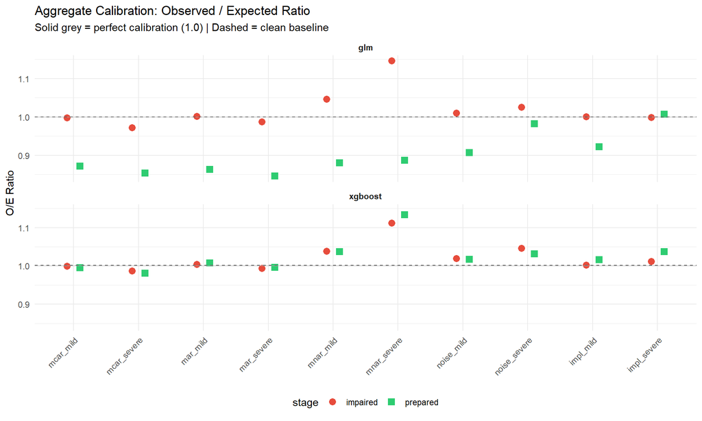

```r
# ── O/E ratio plot ─────────────────────────────────────────────────────

clean_oe <- all_metrics[all_metrics$condition == "clean",
                        c("model_type", "oe_ratio")]

ggplot(plot_metrics, aes(x = condition, y = oe_ratio,
                         color = stage, shape = stage)) +
  geom_point(size = 3, position = position_dodge(width = 0.4)) +
  geom_hline(yintercept = 1.0, linetype = "solid", color = "grey70", linewidth = 0.3) +
  geom_hline(data = clean_oe,
             aes(yintercept = oe_ratio),
             linetype = "dashed", color = "grey40") +
  facet_wrap(~ model_type, ncol = 1) +
  scale_color_manual(values = c(impaired = "#e74c3c", prepared = "#2ecc71")) +
  scale_shape_manual(values = c(impaired = 16, prepared = 15)) +
  labs(title    = "Aggregate Calibration: Observed / Expected Ratio",
       subtitle = "Solid grey = perfect calibration (1.0) | Dashed = clean baseline",
       x = NULL, y = "O/E Ratio") +
  theme_minimal() +
  theme(axis.text.x = element_text(angle = 45, hjust = 1),
        strip.text  = element_text(face = "bold"),
        legend.position = "bottom")
```

**O/E ratio** (pure calibration):

Note that this is a ratio of totals, and errors can cancel out in aggregate (doesn’t look as dramatic as Brier)

Can diverge from Brier when prediction errors are unsystematic

```
• Ersatzwert introduces unsystematic noise to Xgboost predictions (visible in Brier but invisible in O/E), but systematic bias to GLM predictors (visible in both)
• GLM preparation hurts calibration due to the mass-point effect, though at least being under the 1.0 line is safer from a regulatory perspective
• MNAR Severe: an interesting story
    ○ GLM MNAR without preparation underpredicts risk (dangerous). MNAR deletes interest_cov for distressed firms, and complete case analysis deletes all of these firms, so it thinks the risk isn’t there
    ○ Ersatzwert GLM preparation flips it: replaces the missing interest_cov with one value that represents all the distressed firms, therefore overstating the risk. Trading one miscalibration for another
    ○ XGBoost lands on the higher side regardless of preparation. Can't overcome the bias either or learn from the missingness (can overcome MAR perfectly but can't figure this out)
• Implausible and Noise doesn't look too far from the 1.0, but Gini showed meaningful loss in discrimination (dangerous because it might fly under the radar)
```

Implausible mild vs. severe for prepared data: under mild impairment, the winsorizing thresholds are tighter and it clips more into legit variation in the data –> distorts it

### Calibration plot: predicted vs. observed by PD grade

We show this for the clean baseline and all prepared conditions (the ones a practitioner would actually deploy). Impaired conditions are omitted for readability; the prepared-vs-clean comparison is the one that answers the research question.

```r
# ── Calibration plot helper ────────────────────────────────────────────
build_calibration_data <- function(models,
                                   eval_data,
                                   formula,
                                   model_type = c("glm", "xgboost")) {

  model_type <- match.arg(model_type)
  response   <- all.vars(formula)[1]
  predictors <- all.vars(formula)[-1]
  actual     <- eval_data[[response]]

  # Same grade boundaries as assign_pd_grades()
  grade_breaks <- c(0, 0.00001, 0.0006, 0.0011, 0.003,
                    0.007, 0.015, 0.03, 0.08, 0.15, 1.0)
  grade_labels <- as.character(1:10)

  cal_list <- vector("list", length(models))
  names(cal_list) <- names(models)

  for (key in names(models)) {

    mod <- models[[key]]

    if (model_type == "glm") {
      pd_pred <- predict(mod, newdata = eval_data, type = "response")
    } else {
      X <- as.matrix(eval_data[, predictors, drop = FALSE])
      pd_pred <- predict(mod, xgb.DMatrix(data = X))
    }

    grade <- cut(pd_pred,
                 breaks = grade_breaks,
                 labels = grade_labels,
                 include.lowest = TRUE,
                 right = TRUE)

    tmp <- data.frame(pd_pred = pd_pred, actual = actual,
                      grade = as.integer(as.character(grade)))

    agg <- aggregate(cbind(pd_pred, actual) ~ grade, data = tmp, FUN = mean)
    counts <- aggregate(actual ~ grade, data = tmp, FUN = length)
    names(counts)[2] <- "n"
    agg <- merge(agg, counts, by = "grade")

    names(agg)[names(agg) == "pd_pred"] <- "mean_pred_pd"
    names(agg)[names(agg) == "actual"]  <- "obs_default_rate"

    # Parse key
    stage <- ifelse(key == "clean", "clean",
                    ifelse(grepl("^imp_", key), "impaired", "prepared"))
    condition <- ifelse(key == "clean", "clean",
                        sub("^imp_|^prep_", "", key))

    agg$key        <- key
    agg$stage      <- stage
    agg$condition  <- condition
    agg$model_type <- model_type

    cal_list[[key]] <- agg
  }

  cal_df <- do.call(rbind, cal_list)
  rownames(cal_df) <- NULL
  cal_df
}

# ── Build calibration data for both model types ────────────────────────

glm_cal <- build_calibration_data(
  models     = glm_results$models,
  eval_data  = dat,
  formula    = pd_formula,
  model_type = "glm"
)

xgb_cal <- build_calibration_data(
  models     = xgb_results$models,
  eval_data  = dat,
  formula    = pd_formula,
  model_type = "xgboost"
)

all_cal <- rbind(glm_cal, xgb_cal)

# Filter to clean + prepared only (what a practitioner would deploy)
cal_plot_data <- all_cal[all_cal$stage %in% c("clean", "prepared"), ]

# For prepared conditions, parse type + severity for faceting
cal_plot_data$type <- ifelse(
  cal_plot_data$condition == "clean", "clean",
  sub("_mild$|_severe$", "", cal_plot_data$condition)
)
cal_plot_data$severity <- ifelse(
  cal_plot_data$condition == "clean", "none",
  ifelse(grepl("severe", cal_plot_data$condition), "severe", "mild")
)

# Label for faceting: one panel per impairment type
cal_plot_data$facet_label <- ifelse(
  cal_plot_data$condition == "clean", "clean",
  cal_plot_data$condition
)

condition_order <- c("clean",
                     "mcar_mild", "mcar_severe",
                     "mar_mild",  "mar_severe",
                     "mnar_mild", "mnar_severe",
                     "noise_mild", "noise_severe",
                     "impl_mild", "impl_severe")

cal_plot_data$facet_label <- factor(cal_plot_data$facet_label,
                                    levels = condition_order)
```

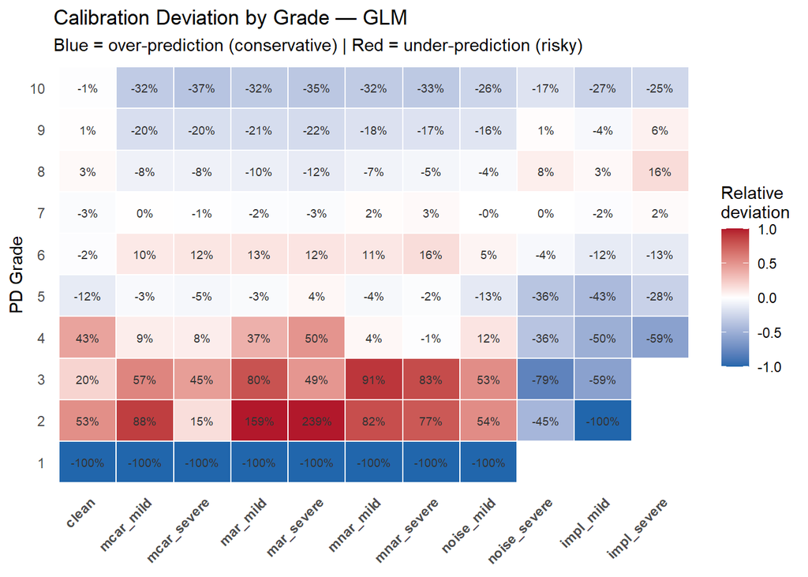

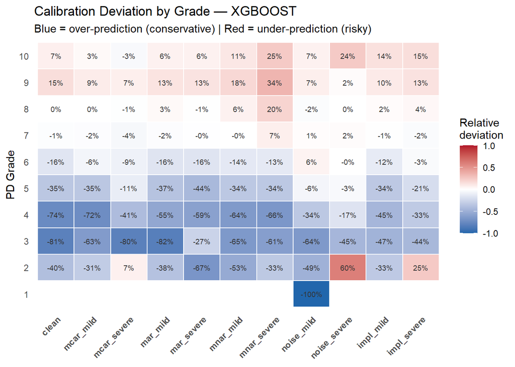

```r
# ── Calibration deviation heatmap ──────────────────────────────────────
library(ggplot2)

# Relative deviation: positive = under-prediction, negative = over-prediction
cal_plot_data$rel_dev <- with(cal_plot_data,
  (obs_default_rate - mean_pred_pd) / pmax(mean_pred_pd, 1e-6)
)

# Cap for visual clarity
cal_plot_data$rel_dev_cap <- pmin(pmax(cal_plot_data$rel_dev, -1), 1)

for (mt in c("glm", "xgboost")) {
  p <- ggplot(cal_plot_data[cal_plot_data$model_type == mt, ],
              aes(x = facet_label, y = factor(grade), fill = rel_dev_cap)) +
    geom_tile(color = "white", linewidth = 0.5) +
    scale_fill_gradient2(
      low = "#2166ac", mid = "white", high = "#b2182b",
      midpoint = 0, limits = c(-1, 1),
      name = "Relative\ndeviation"
    ) +
    geom_text(aes(label = sprintf("%.0f%%", rel_dev * 100)),
              size = 2.5, color = "grey20") +
    labs(
      title = paste0("Calibration Deviation by Grade — ", toupper(mt)),
      subtitle = "Blue = over-prediction (conservative) | Red = under-prediction (risky)",
      x = NULL, y = "PD Grade"
    ) +
    theme_minimal() +
    theme(
      axis.text.x = element_text(angle = 45, hjust = 1, face = "bold"),
      panel.grid   = element_blank()
    )
  print(p)
}
```

Calibration plot (grade-level calibration)

- GLM underestimates the risk on the safe firms (low rating) but overestimates on the risky firms (low rating)
- XGBoost does the opposite (arguably worse), trees are potentially overfit?
- Noise and implausibles for GLM also create more of a dangerous pattern where risky firms are underestimated

### Summary: degradation at a glance

```r
# ── Summary table with deltas from clean ───────────────────────────────

# Get clean baselines
clean_baselines <- all_metrics[all_metrics$condition == "clean",
                               c("model_type", "gini", "brier", "oe_ratio")]
names(clean_baselines) <- c("model_type", "clean_gini", "clean_brier", "clean_oe")

summary_metrics <- merge(all_metrics, clean_baselines, by = "model_type")
summary_metrics$delta_gini  <- summary_metrics$gini  - summary_metrics$clean_gini
summary_metrics$delta_brier <- summary_metrics$brier - summary_metrics$clean_brier
summary_metrics$delta_oe    <- summary_metrics$oe_ratio - summary_metrics$clean_oe

# Order for readability
summary_metrics$condition <- factor(
  summary_metrics$condition,
  levels = c("clean",
             "mcar_mild", "mcar_severe",
             "mar_mild",  "mar_severe",
             "mnar_mild", "mnar_severe",
             "noise_mild", "noise_severe",
             "impl_mild", "impl_severe")
)

summary_metrics <- summary_metrics[order(summary_metrics$model_type,
                                         summary_metrics$condition,
                                         summary_metrics$stage), ]

print(summary_metrics[, c("model_type", "condition", "stage",
                           "gini", "delta_gini",
                           "brier", "delta_brier",
                           "oe_ratio", "delta_oe",
                           "ks")])
```

```
##    model_type    condition    stage      gini    delta_gini      brier
## 1         glm        clean    clean 0.6024250  0.0000000000 0.02147397
## 2         glm    mcar_mild impaired 0.6025506  0.0001255047 0.02147846
## 12        glm    mcar_mild prepared 0.6070018  0.0045767040 0.02184317
## 3         glm  mcar_severe impaired 0.6029819  0.0005568624 0.02148560
## 13        glm  mcar_severe prepared 0.6077947  0.0053696346 0.02203010
## 4         glm     mar_mild impaired 0.6027974  0.0003723834 0.02147832
## 14        glm     mar_mild prepared 0.6038908  0.0014657121 0.02182250
## 5         glm   mar_severe impaired 0.6012077 -0.0012173125 0.02146683
## 15        glm   mar_severe prepared 0.6018171 -0.0006079125 0.02188432
## 6         glm    mnar_mild impaired 0.6038023  0.0013772362 0.02149667
## 16        glm    mnar_mild prepared 0.6066724  0.0042473345 0.02184788
## 7         glm  mnar_severe impaired 0.6045673  0.0021422224 0.02156673
## 17        glm  mnar_severe prepared 0.6070516  0.0046265186 0.02190038
## 8         glm   noise_mild impaired 0.6053449  0.0029198103 0.02151032
```

[output cut: 71 more lines]

# **Stage 6: Monte Carlo**

Assuming the Monte Carlo has been run and stored as an RDS file in the current project directory.

The MC runner (`03_monte_carlo.R`) sources the same functions used throughout this notebook. The full set of tables and figures is produced separately by `04_mc_analysis.R`; here we show the key results.

```r
mc <- readRDS("mc_results_final.rds")

cat(sprintf("Monte Carlo iterations: %d\nFirms per iteration: %d\nTotal metric rows: %d\n",
            mc$config$N_MC, mc$config$N_FIRMS, nrow(mc$metrics)))
```

```
## Monte Carlo iterations: 10
## Firms per iteration: 5000
## Total metric rows: 420
```

```r
# Shared aesthetics
stage_colours <- c(clean = "#2C3E50", impaired = "#E74C3C", prepared = "#2ECC71")

theme_thesis <- theme_minimal(base_size = 11) +
  theme(
    plot.title       = element_text(face = "bold", size = 12),
    strip.text       = element_text(face = "bold"),
    legend.position  = "bottom",
    panel.grid.minor = element_blank()
  )


summary_table <- mc$metrics %>%
  group_by(model_type, type, severity, stage) %>%
  summarise(
    gini_mean = mean(gini),   gini_sd = sd(gini),
    brier_mean = mean(brier), brier_sd = sd(brier),
    oe_mean = mean(oe_ratio), oe_sd = sd(oe_ratio),
    .groups = "drop"
  )

summary_table
```

```
## # A tibble: 42 × 10
##    model_type type  severity stage gini_mean gini_sd brier_mean brier_sd oe_mean
##    <chr>      <chr> <chr>    <chr>     <dbl>   <dbl>      <dbl>    <dbl>   <dbl>
##  1 glm        clean none     clean     0.608 0.00939     0.0217  0.00111   1.000
##  2 glm        impl  mild     impa…     0.594 0.0115      0.0224  0.00109   0.999
##  3 glm        impl  mild     prep…     0.602 0.0103      0.0223  0.00111   0.965
##  4 glm        impl  severe   impa…     0.594 0.0115      0.0224  0.00109   0.997
##  5 glm        impl  severe   prep…     0.591 0.0131      0.0224  0.00109   1.000
##  6 glm        mar   mild     impa…     0.608 0.00950     0.0217  0.00112   0.994
##  7 glm        mar   mild     prep…     0.609 0.00965     0.0221  0.00118   0.863
##  8 glm        mar   severe   impa…     0.607 0.00911     0.0217  0.00110   1.00
##  9 glm        mar   severe   prep…     0.607 0.00932     0.0222  0.00120   0.842
## 10 glm        mcar  mild     impa…     0.608 0.00865     0.0217  0.00111   0.996
## # ℹ 32 more rows
## # ℹ 1 more variable: oe_sd <dbl>
```

## 6.1 Summary Table

The core finding in one table: mean and standard deviation of each metric across all MC iterations, by impairment type, severity, stage, and model architecture. Low standard deviations confirm that single-iteration results were not flukes.

```r
clean_baseline <- mc$metrics %>%
  filter(stage == "clean") %>%
  select(iteration, model_type,
         gini_clean = gini, brier_clean = brier, oe_clean = oe_ratio)

tbl <- mc$metrics %>%
  left_join(clean_baseline, by = c("iteration", "model_type")) %>%
  mutate(
    delta_gini  = gini     - gini_clean,
    delta_brier = brier    - brier_clean,
    delta_oe    = oe_ratio - oe_clean
  ) %>%
  group_by(model_type, type, severity, stage) %>%
  summarise(
    gini_mean  = round(mean(gini), 4),
    gini_sd    = round(sd(gini), 4),
    d_gini     = round(mean(delta_gini), 4),
    brier_mean = round(mean(brier), 6),
    oe_mean    = round(mean(oe_ratio), 4),
    d_oe       = round(mean(delta_oe), 4),
    .groups    = "drop"
  ) %>%
  arrange(model_type, type, severity, match(stage, c("clean", "impaired", "prepared")))

knitr::kable(tbl, caption = "Monte Carlo summary: metric means and standard deviations")
```

Monte Carlo summary: metric means and standard deviations

| model_type | type | severity | stage | gini_mean | gini_sd | d_gini | brier_mean | oe_mean | d_oe |
| --- | --- | --- | --- | --- | --- | --- | --- | --- | --- |
| glm | clean | none | clean | 0.6077 | 0.0094 | 0.0000 | 0.021691 | 1.0000 | 0.0000 |
| glm | impl | mild | impaired | 0.5939 | 0.0115 | -0.0137 | 0.022418 | 0.9987 | -0.0013 |
| glm | impl | mild | prepared | 0.6021 | 0.0103 | -0.0055 | 0.022257 | 0.9646 | -0.0354 |
| glm | impl | severe | impaired | 0.5938 | 0.0115 | -0.0139 | 0.022420 | 0.9968 | -0.0032 |
| glm | impl | severe | prepared | 0.5912 | 0.0131 | -0.0165 | 0.022409 | 0.9999 | -0.0001 |
| glm | mar | mild | impaired | 0.6080 | 0.0095 | 0.0003 | 0.021702 | 0.9942 | -0.0058 |
| glm | mar | mild | prepared | 0.6093 | 0.0097 | 0.0016 | 0.022067 | 0.8626 | -0.1374 |
| glm | mar | severe | impaired | 0.6072 | 0.0091 | -0.0004 | 0.021710 | 1.0043 | 0.0043 |
| glm | mar | severe | prepared | 0.6069 | 0.0093 | -0.0008 | 0.022154 | 0.8418 | -0.1582 |
| glm | mcar | mild | impaired | 0.6078 | 0.0087 | 0.0001 | 0.021704 | 0.9963 | -0.0037 |
| glm | mcar | mild | prepared | 0.6121 | 0.0096 | 0.0044 | 0.022087 | 0.8738 | -0.1262 |
| glm | mcar | severe | impaired | 0.5979 | 0.0094 | -0.0097 | 0.021757 | 1.0382 | 0.0382 |
| glm | mcar | severe | prepared | 0.6118 | 0.0100 | 0.0041 | 0.022251 | 0.8699 | -0.1301 |
| glm | mnar | mild | impaired | 0.6087 | 0.0095 | 0.0010 | 0.021728 | 1.0448 | 0.0448 |
| glm | mnar | mild | prepared | 0.6117 | 0.0095 | 0.0040 | 0.022091 | 0.8797 | -0.1203 |
| glm | mnar | severe | impaired | 0.6081 | 0.0076 | 0.0004 | 0.021822 | 1.1431 | 0.1431 |
| glm | mnar | severe | prepared | 0.6117 | 0.0095 | 0.0041 | 0.022144 | 0.8867 | -0.1133 |
| glm | noise | mild | impaired | 0.6099 | 0.0092 | 0.0023 | 0.021725 | 1.0110 | 0.0110 |
| glm | noise | mild | prepared | 0.6117 | 0.0095 | 0.0040 | 0.021923 | 0.9112 | -0.0888 |
| glm | noise | severe | impaired | 0.6108 | 0.0097 | 0.0031 | 0.021988 | 1.0272 | 0.0272 |
| glm | noise | severe | prepared | 0.6103 | 0.0099 | 0.0027 | 0.022032 | 0.9828 | -0.0172 |
| xgboost | clean | none | clean | 0.8557 | 0.0082 | 0.0000 | 0.018838 | 0.9971 | 0.0000 |
| xgboost | impl | mild | impaired | 0.8318 | 0.0088 | -0.0239 | 0.019270 | 1.0031 | 0.0060 |
| xgboost | impl | mild | prepared | 0.8369 | 0.0097 | -0.0188 | 0.019492 | 1.0215 | 0.0243 |
| xgboost | impl | severe | impaired | 0.7977 | 0.0092 | -0.0580 | 0.019933 | 1.0245 | 0.0274 |
| xgboost | impl | severe | prepared | 0.7908 | 0.0079 | -0.0649 | 0.019928 | 1.0305 | 0.0333 |
| xgboost | mar | mild | impaired | 0.8501 | 0.0096 | -0.0056 | 0.018928 | 0.9923 | -0.0048 |
| xgboost | mar | mild | prepared | 0.8519 | 0.0086 | -0.0038 | 0.019226 | 0.9949 | -0.0022 |
| xgboost | mar | severe | impaired | 0.8315 | 0.0106 | -0.0242 | 0.019133 | 1.0044 | 0.0073 |
| xgboost | mar | severe | prepared | 0.8347 | 0.0082 | -0.0210 | 0.019435 | 1.0061 | 0.0090 |
| xgboost | mcar | mild | impaired | 0.8366 | 0.0090 | -0.0191 | 0.019097 | 0.9940 | -0.0031 |
| xgboost | mcar | mild | prepared | 0.8344 | 0.0094 | -0.0213 | 0.019433 | 0.9913 | -0.0059 |
| xgboost | mcar | severe | impaired | 0.7715 | 0.0088 | -0.0842 | 0.019935 | 1.0470 | 0.0498 |
| xgboost | mcar | severe | prepared | 0.7726 | 0.0095 | -0.0831 | 0.020263 | 1.0269 | 0.0298 |
| xgboost | mnar | mild | impaired | 0.8497 | 0.0084 | -0.0060 | 0.019196 | 1.0431 | 0.0460 |
| xgboost | mnar | mild | prepared | 0.8530 | 0.0069 | -0.0027 | 0.019503 | 1.0414 | 0.0443 |
| xgboost | mnar | severe | impaired | 0.8353 | 0.0091 | -0.0204 | 0.019631 | 1.1253 | 0.1282 |
| xgboost | mnar | severe | prepared | 0.8430 | 0.0088 | -0.0127 | 0.020007 | 1.1340 | 0.1369 |
| xgboost | noise | mild | impaired | 0.7184 | 0.0091 | -0.1373 | 0.020627 | 1.0265 | 0.0294 |
| xgboost | noise | mild | prepared | 0.7172 | 0.0073 | -0.1385 | 0.020872 | 1.0217 | 0.0246 |
| xgboost | noise | severe | impaired | 0.6641 | 0.0093 | -0.1916 | 0.021388 | 1.0287 | 0.0316 |
| xgboost | noise | severe | prepared | 0.6624 | 0.0082 | -0.1933 | 0.021470 | 1.0146 | 0.0175 |

## 6.2 Gini Coefficient — Discrimination Stability

Boxplots across all iterations confirm which impairment types degrade discrimination (Gini drops) and whether Ersatzwert preparation recovers it.

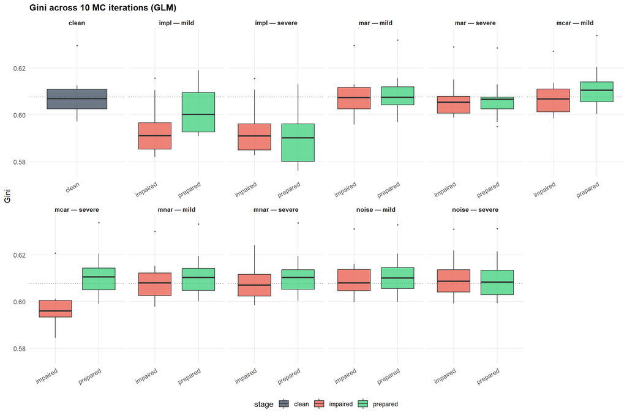

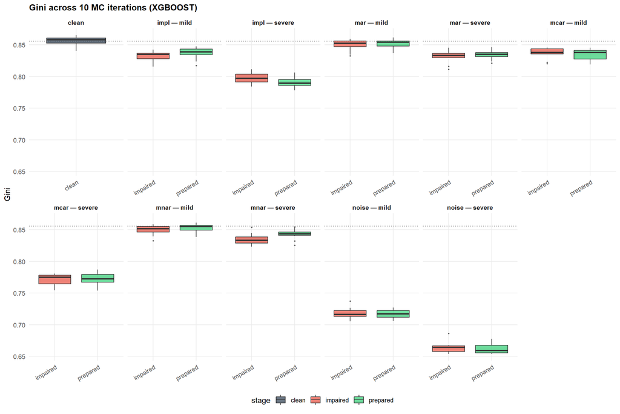

```r
plot_data <- mc$metrics %>%
  mutate(
    stage    = factor(stage, levels = c("clean", "impaired", "prepared")),
    severity = factor(severity, levels = c("none", "mild", "severe")),
    panel    = ifelse(type == "clean", "clean",
                      paste0(type, " — ", severity))
  )

for (mt in c("glm", "xgboost")) {

    clean_gini_mean <- mc$metrics %>%
    filter(model_type == mt, stage == "clean") %>%
    pull(gini) %>% mean()

  p <- ggplot(
    plot_data %>% filter(model_type == mt),
    aes(x = stage, y = gini, fill = stage)
  ) +
    geom_hline(yintercept = clean_gini_mean, linetype = "dotted", colour = "grey40") +
    geom_boxplot(outlier.size = 0.5, alpha = 0.7) +
    scale_fill_manual(values = stage_colours) +
    facet_wrap(~ panel, scales = "free_x", nrow = 2) +
    labs(
      title = sprintf("Gini across %d MC iterations (%s)", mc$config$N_MC, toupper(mt)),
      x = NULL, y = "Gini"
    ) +
    theme_thesis +
    theme(axis.text.x = element_text(angle = 30, hjust = 1))

  print(p)
}
```

## 6.3 O/E Ratio — Calibration Distortion

The O/E ratio reveals whether predicted default rates match observed rates. The dashed line at 1.0 represents perfect calibration.

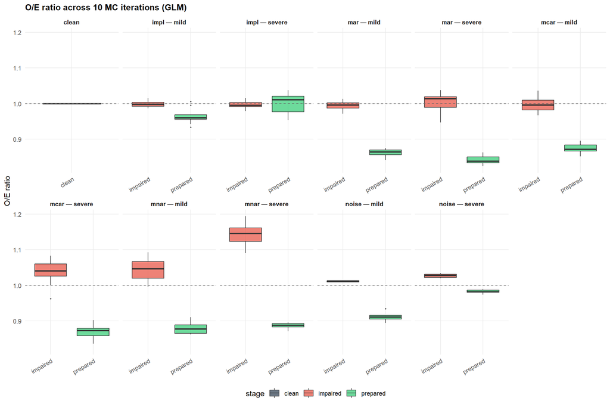

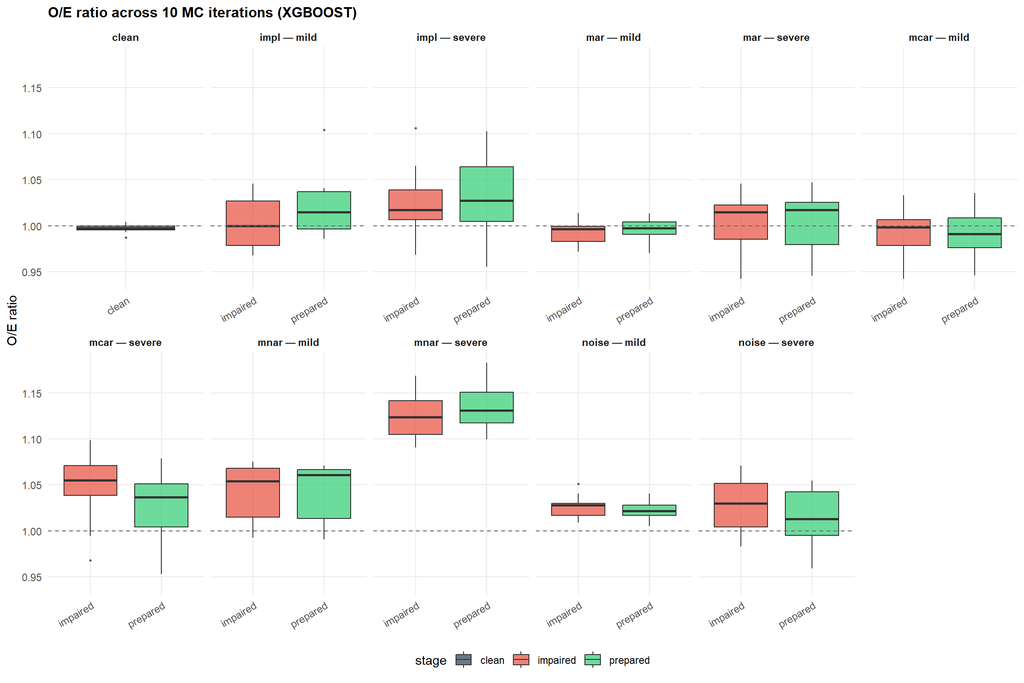

```r
for (mt in c("glm", "xgboost")) {

  p <- ggplot(
    plot_data %>% filter(model_type == mt),
    aes(x = stage, y = oe_ratio, fill = stage)
  ) +
    geom_boxplot(outlier.size = 0.5, alpha = 0.7) +
    geom_hline(yintercept = 1, linetype = "dashed", colour = "grey40") +
    scale_fill_manual(values = stage_colours) +
    facet_wrap(~ panel, scales = "free_x", nrow = 2) +
    labs(
      title = sprintf("O/E ratio across %d MC iterations (%s)", mc$config$N_MC, toupper(mt)),
      x = NULL, y = "O/E ratio"
    ) +
    theme_thesis +
    theme(axis.text.x = element_text(angle = 30, hjust = 1))

  print(p)
}
```

## 6.4 Degradation Heatmap

A single view of mean Gini degradation from each iteration’s clean baseline.

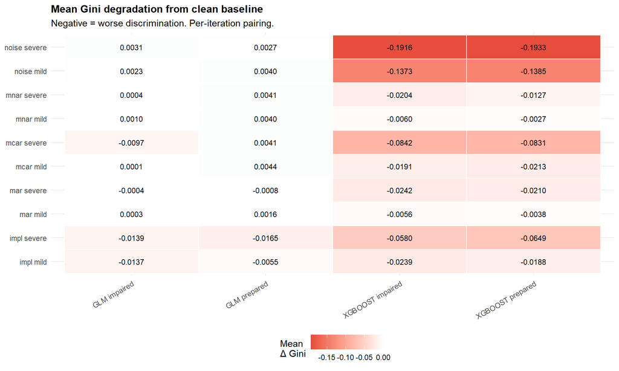

```r
heatmap_data <- mc$metrics %>%
  filter(stage != "clean") %>%
  left_join(clean_baseline, by = c("iteration", "model_type")) %>%
  mutate(delta_gini = gini - gini_clean) %>%
  group_by(model_type, type, severity, stage) %>%
  summarise(delta_gini = mean(delta_gini), .groups = "drop") %>%
  mutate(
    row_label = paste(type, severity),
    col_label = paste(toupper(model_type), stage)
  )

ggplot(heatmap_data, aes(x = col_label, y = row_label, fill = delta_gini)) +
  geom_tile(colour = "white", linewidth = 0.5) +
  geom_text(aes(label = sprintf("%.4f", delta_gini)), size = 3) +
  scale_fill_gradient2(
    low = "#E74C3C", mid = "white", high = "#2ECC71",
    midpoint = 0, name = "Mean\n\u0394 Gini"
  ) +
  labs(
    title = "Mean Gini degradation from clean baseline",
    subtitle = "Negative = worse discrimination. Per-iteration pairing.",
    x = NULL, y = NULL
  ) +
  theme_thesis +
  theme(axis.text.x = element_text(angle = 30, hjust = 1))
```

## 6.5 Coefficient Recovery

GLM coefficients across iterations, with ±1 SD bands. The dashed line marks the true DGP beta for each predictor.

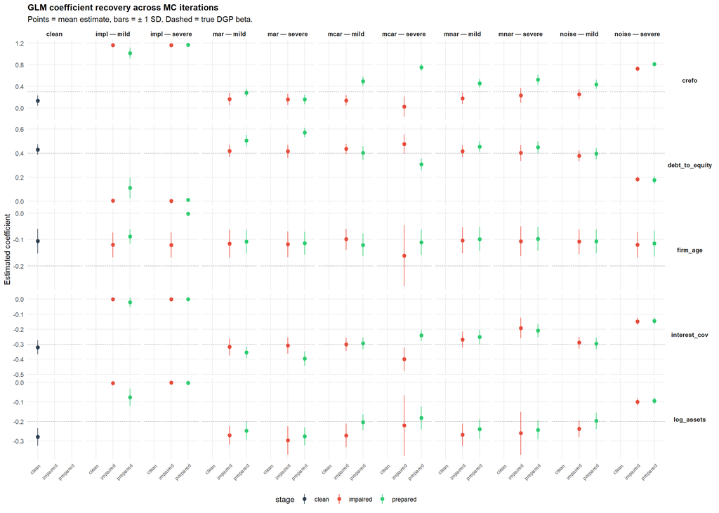

```r
coef_summary <- mc$coefs %>%
  group_by(stage, condition, type, severity, term) %>%
  summarise(
    est_mean = mean(estimated),
    est_lo   = mean(estimated) - sd(estimated),
    est_hi   = mean(estimated) + sd(estimated),
    true_val = first(true),
    .groups  = "drop"
  ) %>%
  mutate(
    stage = factor(stage, levels = c("clean", "impaired", "prepared")),
    panel = ifelse(condition == "clean", "clean",
                   paste0(type, " — ", severity))
  )

key_terms <- c("log_assets", "debt_to_equity", "interest_cov",
               "firm_age", "crefo")

ggplot(
  coef_summary %>% filter(term %in% key_terms),
  aes(x = stage, y = est_mean, colour = stage)
) +
  geom_pointrange(aes(ymin = est_lo, ymax = est_hi), size = 0.4) +
  geom_hline(aes(yintercept = true_val), linetype = "dashed",
             colour = "grey50", linewidth = 0.3) +
  scale_colour_manual(values = stage_colours) +
  facet_grid(term ~ panel, scales = "free_y") +
  labs(
    title = "GLM coefficient recovery across MC iterations",
    subtitle = "Points = mean estimate, bars = \u00B1 1 SD. Dashed = true DGP beta.",
    x = NULL, y = "Estimated coefficient"
  ) +
  theme_thesis +
  theme(
    axis.text.x  = element_text(angle = 45, hjust = 1, size = 7),
    strip.text.y = element_text(angle = 0)
  )
```